# 3. Ders: Değişkenlik Ölçüleri ve İki Değişken Arasındaki İlişki

Çalışma soruları

← Çalışma soruları · Sunum

## Kavramları yoklama

Bir mahalledeki dokuz dairenin satış fiyatı (milyon TL):

$$4,\ 16,\ 13,\ 8,\ 10,\ 6,\ 9,\ 12,\ 14$$

Mahallede 120 milyon TL’lik bir villa satılıyor. Hesap yapmadan tahmin edin: her ölçü nasıl etkilenir?

- Aralık:
- Kartiller aralığı (IQR):
- Standart sapma:
- Ortalama:
- Medyan:

| Ölçü | Önce | Sonra |
| --- | --- | --- |
| Aralık | 12.00 | 116.00 |
| Kartiller aralığı (IQR) | 6.50 | 7.00 |
| Standart sapma | 3.90 | 34.91 |
| Ortalama | 10.22 | 21.20 |
| Medyan | 10.00 | 11.00 |

**Aralık** yalnızca en büyük ve en küçük gözleme bakar; yeni gözlem en büyük değer olduğu için aralık onunla birlikte büyür. **Ortalama** ve **standart sapma** bütün gözlemlerin değerini kullanır. Uç değerin ortalamadan uzaklığı standart sapmada karesiyle girdiği için standart sapma özellikle çok büyür.

**Medyan** ve **kartiller** sıralamaya dayanır. Yeni gözlem sıralamanın en sonuna eklenir; ortadaki değerler yalnızca bir sıra kayar. Uç değerin 10 kat ya da 100 kat büyük olması sonucu değiştirmez. Bu ölçülere uç değerlere **dirençli** denir.

Bir mahalledeki dokuz dairenin satış fiyatı (milyon TL):

$$12,\ 7,\ 11,\ 4,\ 10,\ 15,\ 8,\ 14,\ 6$$

Mahallede 60 milyon TL’lik bir villa satılıyor. Hesap yapmadan tahmin edin: her ölçü nasıl etkilenir?

- Aralık:
- Kartiller aralığı (IQR):
- Standart sapma:
- Ortalama:
- Medyan:

| Ölçü | Önce | Sonra |
| --- | --- | --- |
| Aralık | 11.00 | 56.00 |
| Kartiller aralığı (IQR) | 6.50 | 7.50 |
| Standart sapma | 3.71 | 16.30 |
| Ortalama | 9.67 | 14.70 |
| Medyan | 10.00 | 10.50 |

**Aralık** yalnızca en büyük ve en küçük gözleme bakar; yeni gözlem en büyük değer olduğu için aralık onunla birlikte büyür. **Ortalama** ve **standart sapma** bütün gözlemlerin değerini kullanır. Uç değerin ortalamadan uzaklığı standart sapmada karesiyle girdiği için standart sapma özellikle çok büyür.

**Medyan** ve **kartiller** sıralamaya dayanır. Yeni gözlem sıralamanın en sonuna eklenir; ortadaki değerler yalnızca bir sıra kayar. Uç değerin 10 kat ya da 100 kat büyük olması sonucu değiştirmez. Bu ölçülere uç değerlere **dirençli** denir.

Bir mahalledeki dokuz dairenin satış fiyatı (milyon TL):

$$3,\ 12,\ 16,\ 13,\ 15,\ 5,\ 10,\ 4,\ 11$$

Mahallede 60 milyon TL’lik bir villa satılıyor. Hesap yapmadan tahmin edin: her ölçü nasıl etkilenir?

- Aralık:
- Kartiller aralığı (IQR):
- Standart sapma:
- Ortalama:
- Medyan:

| Ölçü | Önce | Sonra |
| --- | --- | --- |
| Aralık | 13.00 | 57.00 |
| Kartiller aralığı (IQR) | 9.50 | 10.50 |
| Standart sapma | 4.81 | 16.48 |
| Ortalama | 9.89 | 14.90 |
| Medyan | 11.00 | 11.50 |

**Aralık** yalnızca en büyük ve en küçük gözleme bakar; yeni gözlem en büyük değer olduğu için aralık onunla birlikte büyür. **Ortalama** ve **standart sapma** bütün gözlemlerin değerini kullanır. Uç değerin ortalamadan uzaklığı standart sapmada karesiyle girdiği için standart sapma özellikle çok büyür.

**Medyan** ve **kartiller** sıralamaya dayanır. Yeni gözlem sıralamanın en sonuna eklenir; ortadaki değerler yalnızca bir sıra kayar. Uç değerin 10 kat ya da 100 kat büyük olması sonucu değiştirmez. Bu ölçülere uç değerlere **dirençli** denir.

Bir mahalledeki dokuz dairenin satış fiyatı (milyon TL):

$$16,\ 3,\ 7,\ 9,\ 5,\ 14,\ 10,\ 11,\ 8$$

Mahallede 60 milyon TL’lik bir villa satılıyor. Hesap yapmadan tahmin edin: her ölçü nasıl etkilenir?

- Aralık:
- Kartiller aralığı (IQR):
- Standart sapma:
- Ortalama:
- Medyan:

| Ölçü | Önce | Sonra |
| --- | --- | --- |
| Aralık | 13.00 | 57.00 |
| Kartiller aralığı (IQR) | 6.50 | 8.00 |
| Standart sapma | 4.12 | 16.52 |
| Ortalama | 9.22 | 14.30 |
| Medyan | 9.00 | 9.50 |

**Aralık** yalnızca en büyük ve en küçük gözleme bakar; yeni gözlem en büyük değer olduğu için aralık onunla birlikte büyür. **Ortalama** ve **standart sapma** bütün gözlemlerin değerini kullanır. Uç değerin ortalamadan uzaklığı standart sapmada karesiyle girdiği için standart sapma özellikle çok büyür.

**Medyan** ve **kartiller** sıralamaya dayanır. Yeni gözlem sıralamanın en sonuna eklenir; ortadaki değerler yalnızca bir sıra kayar. Uç değerin 10 kat ya da 100 kat büyük olması sonucu değiştirmez. Bu ölçülere uç değerlere **dirençli** denir.

Aşağıda üç veri kümesinin histogramı var. Üçünde de ortalama yaklaşık 50, en küçük gözlem 0, en büyük gözlem 100.

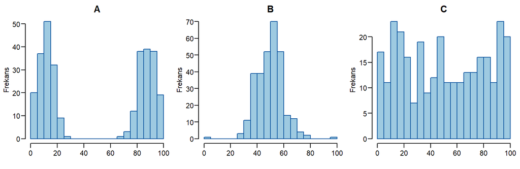

- Standart sapması **en büyük** olan:
- Standart sapması **en küçük** olan:

Standart sapmalar: A = 38.5, B = 10.1, C = 30.6.

Standart sapma, gözlemlerin **ortalamadan tipik uzaklığıdır**. Gözlemleri ortalamanın (50) çevresinde toplanmış veri kümesinde uzaklıklar küçüktür; gözlemleri iki uca yığılmış veri kümesinde neredeyse her gözlem ortalamadan 35-40 birim uzaktadır. Düz dağılmış veri ikisinin arasındadır.

Üç veri kümesinin **aralığı aynıdır** (100). Aralık yalnızca en uçtaki iki gözleme baktığı için bu farkı göremez. Yayılımı karşılaştırırken histograma bakmak ya da bütün gözlemleri kullanan bir ölçü seçmek gerekir.

Aşağıda üç veri kümesinin histogramı var. Üçünde de ortalama yaklaşık 50, en küçük gözlem 0, en büyük gözlem 100.

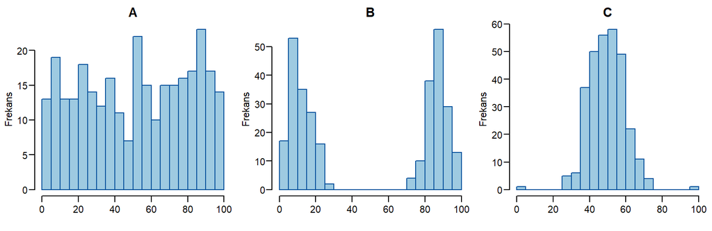

- Standart sapması **en büyük** olan:
- Standart sapması **en küçük** olan:

Standart sapmalar: A = 29.7, B = 38.1, C = 9.9.

Standart sapma, gözlemlerin **ortalamadan tipik uzaklığıdır**. Gözlemleri ortalamanın (50) çevresinde toplanmış veri kümesinde uzaklıklar küçüktür; gözlemleri iki uca yığılmış veri kümesinde neredeyse her gözlem ortalamadan 35-40 birim uzaktadır. Düz dağılmış veri ikisinin arasındadır.

Üç veri kümesinin **aralığı aynıdır** (100). Aralık yalnızca en uçtaki iki gözleme baktığı için bu farkı göremez. Yayılımı karşılaştırırken histograma bakmak ya da bütün gözlemleri kullanan bir ölçü seçmek gerekir.

Aşağıda üç veri kümesinin histogramı var. Üçünde de ortalama yaklaşık 50, en küçük gözlem 0, en büyük gözlem 100.

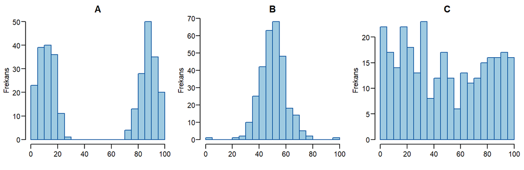

- Standart sapması **en büyük** olan:
- Standart sapması **en küçük** olan:

Standart sapmalar: A = 38.6, B = 9.8, C = 30.8.

Standart sapma, gözlemlerin **ortalamadan tipik uzaklığıdır**. Gözlemleri ortalamanın (50) çevresinde toplanmış veri kümesinde uzaklıklar küçüktür; gözlemleri iki uca yığılmış veri kümesinde neredeyse her gözlem ortalamadan 35-40 birim uzaktadır. Düz dağılmış veri ikisinin arasındadır.

Üç veri kümesinin **aralığı aynıdır** (100). Aralık yalnızca en uçtaki iki gözleme baktığı için bu farkı göremez. Yayılımı karşılaştırırken histograma bakmak ya da bütün gözlemleri kullanan bir ölçü seçmek gerekir.

Aşağıda üç veri kümesinin histogramı var. Üçünde de ortalama yaklaşık 50, en küçük gözlem 0, en büyük gözlem 100.

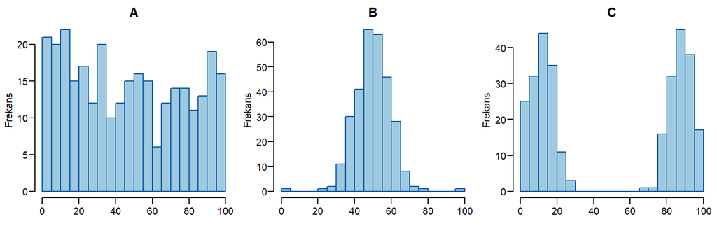

- Standart sapması **en büyük** olan:
- Standart sapması **en küçük** olan:

Standart sapmalar: A = 30.5, B = 9.9, C = 38.3.

Standart sapma, gözlemlerin **ortalamadan tipik uzaklığıdır**. Gözlemleri ortalamanın (50) çevresinde toplanmış veri kümesinde uzaklıklar küçüktür; gözlemleri iki uca yığılmış veri kümesinde neredeyse her gözlem ortalamadan 35-40 birim uzaktadır. Düz dağılmış veri ikisinin arasındadır.

Üç veri kümesinin **aralığı aynıdır** (100). Aralık yalnızca en uçtaki iki gözleme baktığı için bu farkı göremez. Yayılımı karşılaştırırken histograma bakmak ya da bütün gözlemleri kullanan bir ölçü seçmek gerekir.

Değişkenlik katsayısı $CV = 100 \cdot s / \bar{x}$ aşağıdaki değişkenlerden hangisi için **anlamlı bir ölçü değildir**?

Ülkelerin yıllık ekonomik büyüme hızı (%; küçülen ülkeler için negatif)Öğrencilerin kampüse geliş süresi (dakika)Firmaların çalışan sayısıDairelerin aylık kirası (TL)

Doğru yanıt: **Ülkelerin yıllık ekonomik büyüme hızı (%; küçülen ülkeler için negatif)**. Büyüme hızı negatif olabilir ve ortalaması sıfıra yakın çıkabilir. Ortalama sıfıra yaklaştıkça CV sonsuza gider; bu durumda yayılımı standart sapmayla ya da IQR ile raporlamak gerekir.

CV bir **orandır**: standart sapmanın ortalamanın yüzde kaçı olduğunu söyler. Bu yüzden yalnızca gerçek bir sıfır noktası olan ve pozitif değerler alan (oransal ölçekteki) değişkenlerde anlamlıdır: harcama, boy, ağırlık, süre, sayılar.

Değişkenlik katsayısı $CV = 100 \cdot s / \bar{x}$ aşağıdaki değişkenlerden hangisi için **anlamlı bir ölçü değildir**?

Hisse senetlerinin günlük getirisi (%; düşüş günlerinde negatif)Yetişkinlerin boyu (cm)Günlük sipariş sayısıPaketlerin ağırlığı (gram)

Doğru yanıt: **Hisse senetlerinin günlük getirisi (%; düşüş günlerinde negatif)**. Günlük getirilerin ortalaması sıfıra çok yakındır ve negatif değerler olağandır. Sıfıra yakın bir ortalamaya bölmek anlamsız derecede büyük ya da işareti değişen bir CV verir.

CV bir **orandır**: standart sapmanın ortalamanın yüzde kaçı olduğunu söyler. Bu yüzden yalnızca gerçek bir sıfır noktası olan ve pozitif değerler alan (oransal ölçekteki) değişkenlerde anlamlıdır: harcama, boy, ağırlık, süre, sayılar.

Değişkenlik katsayısı $CV = 100 \cdot s / \bar{x}$ aşağıdaki değişkenlerden hangisi için **anlamlı bir ölçü değildir**?

Yetişkinlerin boyu (cm)Günlük sipariş sayısıDairelerin aylık kirası (TL)Ülkelerin yıllık ekonomik büyüme hızı (%; küçülen ülkeler için negatif)

Doğru yanıt: **Ülkelerin yıllık ekonomik büyüme hızı (%; küçülen ülkeler için negatif)**. Büyüme hızı negatif olabilir ve ortalaması sıfıra yakın çıkabilir. Ortalama sıfıra yaklaştıkça CV sonsuza gider; bu durumda yayılımı standart sapmayla ya da IQR ile raporlamak gerekir.

CV bir **orandır**: standart sapmanın ortalamanın yüzde kaçı olduğunu söyler. Bu yüzden yalnızca gerçek bir sıfır noktası olan ve pozitif değerler alan (oransal ölçekteki) değişkenlerde anlamlıdır: harcama, boy, ağırlık, süre, sayılar.

Değişkenlik katsayısı $CV = 100 \cdot s / \bar{x}$ aşağıdaki değişkenlerden hangisi için **anlamlı bir ölçü değildir**?

Günlük sipariş sayısıHanelerin aylık gıda harcaması (TL)Firmaların yıllık net kârı (milyon TL; zarar eden firmalar için negatif)Yetişkinlerin boyu (cm)

Doğru yanıt: **Firmaların yıllık net kârı (milyon TL; zarar eden firmalar için negatif)**. Değişken negatif değer alabildiği için ortalama sıfıra yakın, hatta negatif çıkabilir. Ortalama sıfıra yaklaştıkça CV sonsuza gider; negatif ortalamada anlamını tamamen yitirir.

CV bir **orandır**: standart sapmanın ortalamanın yüzde kaçı olduğunu söyler. Bu yüzden yalnızca gerçek bir sıfır noktası olan ve pozitif değerler alan (oransal ölçekteki) değişkenlerde anlamlıdır: harcama, boy, ağırlık, süre, sayılar.

Değişkenlik katsayısı $CV = 100 \cdot s / \bar{x}$ aşağıdaki değişkenlerden hangisi için **anlamlı bir ölçü değildir**?

Günlük sipariş sayısıFirmaların yıllık net kârı (milyon TL; zarar eden firmalar için negatif)Firmaların çalışan sayısıYetişkinlerin boyu (cm)

Doğru yanıt: **Firmaların yıllık net kârı (milyon TL; zarar eden firmalar için negatif)**. Değişken negatif değer alabildiği için ortalama sıfıra yakın, hatta negatif çıkabilir. Ortalama sıfıra yaklaştıkça CV sonsuza gider; negatif ortalamada anlamını tamamen yitirir.

CV bir **orandır**: standart sapmanın ortalamanın yüzde kaçı olduğunu söyler. Bu yüzden yalnızca gerçek bir sıfır noktası olan ve pozitif değerler alan (oransal ölçekteki) değişkenlerde anlamlıdır: harcama, boy, ağırlık, süre, sayılar.

Değişkenlik katsayısı $CV = 100 \cdot s / \bar{x}$ aşağıdaki değişkenlerden hangisi için **anlamlı bir ölçü değildir**?

Yetişkinlerin boyu (cm)Hanelerin aylık gıda harcaması (TL)Firmaların yıllık net kârı (milyon TL; zarar eden firmalar için negatif)Dairelerin aylık kirası (TL)

Doğru yanıt: **Firmaların yıllık net kârı (milyon TL; zarar eden firmalar için negatif)**. Değişken negatif değer alabildiği için ortalama sıfıra yakın, hatta negatif çıkabilir. Ortalama sıfıra yaklaştıkça CV sonsuza gider; negatif ortalamada anlamını tamamen yitirir.

CV bir **orandır**: standart sapmanın ortalamanın yüzde kaçı olduğunu söyler. Bu yüzden yalnızca gerçek bir sıfır noktası olan ve pozitif değerler alan (oransal ölçekteki) değişkenlerde anlamlıdır: harcama, boy, ağırlık, süre, sayılar.

Değişkenlik katsayısı $CV = 100 \cdot s / \bar{x}$ aşağıdaki değişkenlerden hangisi için **anlamlı bir ölçü değildir**?

Paketlerin ağırlığı (gram)Öğrencilerin kampüse geliş süresi (dakika)Bir ilin günlük ortalama sıcaklığı (°C)Hanelerin aylık gıda harcaması (TL)

Doğru yanıt: **Bir ilin günlük ortalama sıcaklığı (°C)**. Celsius ölçeğinde sıfır noktası keyfidir (aralık ölçeği). Aynı sıcaklıklar Fahrenheit ile yazılınca ortalama değişir, standart sapma ise 1.8 ile çarpılır; ikisinin oranı birim değişince değişir. Oran almanın anlamlı olmadığı bir değişkende CV de anlamsızdır.

CV bir **orandır**: standart sapmanın ortalamanın yüzde kaçı olduğunu söyler. Bu yüzden yalnızca gerçek bir sıfır noktası olan ve pozitif değerler alan (oransal ölçekteki) değişkenlerde anlamlıdır: harcama, boy, ağırlık, süre, sayılar.

Değişkenlik katsayısı $CV = 100 \cdot s / \bar{x}$ aşağıdaki değişkenlerden hangisi için **anlamlı bir ölçü değildir**?

Dairelerin aylık kirası (TL)Bir ilin günlük ortalama sıcaklığı (°C)Günlük sipariş sayısıYetişkinlerin boyu (cm)

Doğru yanıt: **Bir ilin günlük ortalama sıcaklığı (°C)**. Celsius ölçeğinde sıfır noktası keyfidir (aralık ölçeği). Aynı sıcaklıklar Fahrenheit ile yazılınca ortalama değişir, standart sapma ise 1.8 ile çarpılır; ikisinin oranı birim değişince değişir. Oran almanın anlamlı olmadığı bir değişkende CV de anlamsızdır.

CV bir **orandır**: standart sapmanın ortalamanın yüzde kaçı olduğunu söyler. Bu yüzden yalnızca gerçek bir sıfır noktası olan ve pozitif değerler alan (oransal ölçekteki) değişkenlerde anlamlıdır: harcama, boy, ağırlık, süre, sayılar.

Bir veri kümesi (kolay bir sınavdan alınan notlar) için çarpıklık katsayısı $c = -0.9$, basıklık katsayısı $b = 3.05$ bulunmuştur.

- Dağılımın biçimi:
- Ortalama ile medyan:
- Kuyruklar:

**Çarpıklık.** $c = -0.9$: negatif, dağılım **sola çarpık**; uzun kuyruk solda. Soldaki küçük değerler ortalamayı aşağı çeker, ortalama medyandan küçük olur.

**Basıklık.** Normal dağılımda $b = 3$. $b = 3.05$: 3’e çok yakın; kuyruklar normal dağılımınkine benzer.

Çarpıklık katsayısında sapmaların **küpü**, basıklıkta **dördüncü kuvveti** alınır. Bu yüzden ikisini de ortalamadan uzak gözlemler belirler: çarpıklıkta uzak gözlemlerin hangi tarafta olduğu, basıklıkta ne kadar sık ve ne kadar uzak oldukları.

Bir veri kümesi (bir ilçedeki dairelerin aylık kirası) için çarpıklık katsayısı $c = -0.05$, basıklık katsayısı $b = 1.9$ bulunmuştur.

- Dağılımın biçimi:
- Ortalama ile medyan:
- Kuyruklar:

**Çarpıklık.** $c = -0.05$: sıfıra çok yakın, dağılım **yaklaşık simetrik**; ortalama ile medyan birbirine yakındır.

**Basıklık.** Normal dağılımda $b = 3$. $b = 1.9$: 3’ten belirgin biçimde küçük; dağılım **basık** (platikurtik), kuyrukları ince. Aşırı değerler normal dağılıma göre daha seyrektir.

Çarpıklık katsayısında sapmaların **küpü**, basıklıkta **dördüncü kuvveti** alınır. Bu yüzden ikisini de ortalamadan uzak gözlemler belirler: çarpıklıkta uzak gözlemlerin hangi tarafta olduğu, basıklıkta ne kadar sık ve ne kadar uzak oldukları.

Bir veri kümesi (bir fabrikadaki paket ağırlıkları) için çarpıklık katsayısı $c = 0.03$, basıklık katsayısı $b = 8.2$ bulunmuştur.

- Dağılımın biçimi:
- Ortalama ile medyan:
- Kuyruklar:

**Çarpıklık.** $c = 0.03$: sıfıra çok yakın, dağılım **yaklaşık simetrik**; ortalama ile medyan birbirine yakındır.

**Basıklık.** Normal dağılımda $b = 3$. $b = 8.2$: 3’ten belirgin biçimde büyük; dağılım **sivri** (leptokurtik), kuyrukları kalın. Aşırı değerler normal dağılımın öngördüğünden daha sık görülür. Finansal getirilerde tipik bir durumdur.

Çarpıklık katsayısında sapmaların **küpü**, basıklıkta **dördüncü kuvveti** alınır. Bu yüzden ikisini de ortalamadan uzak gözlemler belirler: çarpıklıkta uzak gözlemlerin hangi tarafta olduğu, basıklıkta ne kadar sık ve ne kadar uzak oldukları.

Bir veri kümesi (bir hisse senedinin günlük getirisi) için çarpıklık katsayısı $c = 0.03$, basıklık katsayısı $b = 8.2$ bulunmuştur.

- Dağılımın biçimi:
- Ortalama ile medyan:
- Kuyruklar:

**Çarpıklık.** $c = 0.03$: sıfıra çok yakın, dağılım **yaklaşık simetrik**; ortalama ile medyan birbirine yakındır.

**Basıklık.** Normal dağılımda $b = 3$. $b = 8.2$: 3’ten belirgin biçimde büyük; dağılım **sivri** (leptokurtik), kuyrukları kalın. Aşırı değerler normal dağılımın öngördüğünden daha sık görülür. Finansal getirilerde tipik bir durumdur.

Çarpıklık katsayısında sapmaların **küpü**, basıklıkta **dördüncü kuvveti** alınır. Bu yüzden ikisini de ortalamadan uzak gözlemler belirler: çarpıklıkta uzak gözlemlerin hangi tarafta olduğu, basıklıkta ne kadar sık ve ne kadar uzak oldukları.

Bir veri kümesi (bir ürüne verilen puanlar) için çarpıklık katsayısı $c = -0.9$, basıklık katsayısı $b = 8.2$ bulunmuştur.

- Dağılımın biçimi:
- Ortalama ile medyan:
- Kuyruklar:

**Çarpıklık.** $c = -0.9$: negatif, dağılım **sola çarpık**; uzun kuyruk solda. Soldaki küçük değerler ortalamayı aşağı çeker, ortalama medyandan küçük olur.

**Basıklık.** Normal dağılımda $b = 3$. $b = 8.2$: 3’ten belirgin biçimde büyük; dağılım **sivri** (leptokurtik), kuyrukları kalın. Aşırı değerler normal dağılımın öngördüğünden daha sık görülür. Finansal getirilerde tipik bir durumdur.

Çarpıklık katsayısında sapmaların **küpü**, basıklıkta **dördüncü kuvveti** alınır. Bu yüzden ikisini de ortalamadan uzak gözlemler belirler: çarpıklıkta uzak gözlemlerin hangi tarafta olduğu, basıklıkta ne kadar sık ve ne kadar uzak oldukları.

Bir veri kümesi (bir kargo firmasının teslim süreleri) için çarpıklık katsayısı $c = -0.05$, basıklık katsayısı $b = 1.9$ bulunmuştur.

- Dağılımın biçimi:
- Ortalama ile medyan:
- Kuyruklar:

**Çarpıklık.** $c = -0.05$: sıfıra çok yakın, dağılım **yaklaşık simetrik**; ortalama ile medyan birbirine yakındır.

**Basıklık.** Normal dağılımda $b = 3$. $b = 1.9$: 3’ten belirgin biçimde küçük; dağılım **basık** (platikurtik), kuyrukları ince. Aşırı değerler normal dağılıma göre daha seyrektir.

Çarpıklık katsayısında sapmaların **küpü**, basıklıkta **dördüncü kuvveti** alınır. Bu yüzden ikisini de ortalamadan uzak gözlemler belirler: çarpıklıkta uzak gözlemlerin hangi tarafta olduğu, basıklıkta ne kadar sık ve ne kadar uzak oldukları.

Bir veri kümesi (bir hisse senedinin günlük getirisi) için çarpıklık katsayısı $c = -0.05$, basıklık katsayısı $b = 3.05$ bulunmuştur.

- Dağılımın biçimi:
- Ortalama ile medyan:
- Kuyruklar:

**Çarpıklık.** $c = -0.05$: sıfıra çok yakın, dağılım **yaklaşık simetrik**; ortalama ile medyan birbirine yakındır.

**Basıklık.** Normal dağılımda $b = 3$. $b = 3.05$: 3’e çok yakın; kuyruklar normal dağılımınkine benzer.

Çarpıklık katsayısında sapmaların **küpü**, basıklıkta **dördüncü kuvveti** alınır. Bu yüzden ikisini de ortalamadan uzak gözlemler belirler: çarpıklıkta uzak gözlemlerin hangi tarafta olduğu, basıklıkta ne kadar sık ve ne kadar uzak oldukları.

Bir veri kümesi (kolay bir sınavdan alınan notlar) için çarpıklık katsayısı $c = 0.03$, basıklık katsayısı $b = 3.05$ bulunmuştur.

- Dağılımın biçimi:
- Ortalama ile medyan:
- Kuyruklar:

**Çarpıklık.** $c = 0.03$: sıfıra çok yakın, dağılım **yaklaşık simetrik**; ortalama ile medyan birbirine yakındır.

**Basıklık.** Normal dağılımda $b = 3$. $b = 3.05$: 3’e çok yakın; kuyruklar normal dağılımınkine benzer.

Çarpıklık katsayısında sapmaların **küpü**, basıklıkta **dördüncü kuvveti** alınır. Bu yüzden ikisini de ortalamadan uzak gözlemler belirler: çarpıklıkta uzak gözlemlerin hangi tarafta olduğu, basıklıkta ne kadar sık ve ne kadar uzak oldukları.

## Uygulama ve yorum

### Değişkenlik

Bir öğrenci evinde yaşayanların haftalık harcaması (yüz TL), $n = 7$:

$$21,\ 12,\ 26,\ 21,\ 6,\ 16,\ 24$$

- Ortalama $\bar{x}$:
- Sapma kareleri toplamı $\sum (x_i - \bar{x})^2$:
- Örneklem varyansı $s^2$ (iki ondalık):
- Örneklem standart sapması $s$ (iki ondalık):
- Bu 7 gözlem ilgilendiğimiz birimlerin **tamamı** (anakütle) olsaydı varyans $\sigma^2$ (iki ondalık):

$\bar{x} = 126 / 7 = 18$

| $i$ | $x_i$ | $x_i - \bar{x}$ | $(x_i - \bar{x})^2$ |
| --- | --- | --- | --- |
| 1 | 21 | 3 | 9 |
| 2 | 12 | -6 | 36 |
| 3 | 26 | 8 | 64 |
| 4 | 21 | 3 | 9 |
| 5 | 6 | -12 | 144 |
| 6 | 16 | -2 | 4 |
| 7 | 24 | 6 | 36 |
| **Toplam** | **126** | **0** | **302** |

Sapmaların toplamı her zaman sıfırdır; bu yüzden karelerine bakılır.

$$s^2 = \frac{\sum (x_i - \bar{x})^2}{n - 1} = \frac{302}{6} = 50.33, \qquad s = \sqrt{50.33} = 7.09$$

Anakütlede $N$’ye bölünür: $\sigma^2 = 302 / 7 = 43.14$. Örneklemde $n - 1$’e bölmenin nedeni İstatistik II’de.

Standart sapma verinin birimindedir ve “gözlemlerin ortalamadan tipik uzaklığı” olarak yorumlanır; varyansın birimi verinin biriminin karesidir.

Bir şubede günlük teslim edilen paket sayısı (onlarca), $n = 6$:

$$19,\ 19,\ 11,\ 17,\ 20,\ 16$$

- Ortalama $\bar{x}$:
- Sapma kareleri toplamı $\sum (x_i - \bar{x})^2$:
- Örneklem varyansı $s^2$ (iki ondalık):
- Örneklem standart sapması $s$ (iki ondalık):
- Bu 6 gözlem ilgilendiğimiz birimlerin **tamamı** (anakütle) olsaydı varyans $\sigma^2$ (iki ondalık):

$\bar{x} = 102 / 6 = 17$

| $i$ | $x_i$ | $x_i - \bar{x}$ | $(x_i - \bar{x})^2$ |
| --- | --- | --- | --- |
| 1 | 19 | 2 | 4 |
| 2 | 19 | 2 | 4 |
| 3 | 11 | -6 | 36 |
| 4 | 17 | 0 | 0 |
| 5 | 20 | 3 | 9 |
| 6 | 16 | -1 | 1 |
| **Toplam** | **102** | **0** | **54** |

Sapmaların toplamı her zaman sıfırdır; bu yüzden karelerine bakılır.

$$s^2 = \frac{\sum (x_i - \bar{x})^2}{n - 1} = \frac{54}{5} = 10.80, \qquad s = \sqrt{10.80} = 3.29$$

Anakütlede $N$’ye bölünür: $\sigma^2 = 54 / 6 = 9.00$. Örneklemde $n - 1$’e bölmenin nedeni İstatistik II’de.

Standart sapma verinin birimindedir ve “gözlemlerin ortalamadan tipik uzaklığı” olarak yorumlanır; varyansın birimi verinin biriminin karesidir.

Bir öğrencinin kısa sınavlardan aldığı notlar, $n = 7$:

$$51,\ 79,\ 63,\ 67,\ 95,\ 93,\ 91$$

- Ortalama $\bar{x}$:
- Sapma kareleri toplamı $\sum (x_i - \bar{x})^2$:
- Örneklem varyansı $s^2$ (iki ondalık):
- Örneklem standart sapması $s$ (iki ondalık):
- Bu 7 gözlem ilgilendiğimiz birimlerin **tamamı** (anakütle) olsaydı varyans $\sigma^2$ (iki ondalık):

$\bar{x} = 539 / 7 = 77$

| $i$ | $x_i$ | $x_i - \bar{x}$ | $(x_i - \bar{x})^2$ |
| --- | --- | --- | --- |
| 1 | 51 | -26 | 676 |
| 2 | 79 | 2 | 4 |
| 3 | 63 | -14 | 196 |
| 4 | 67 | -10 | 100 |
| 5 | 95 | 18 | 324 |
| 6 | 93 | 16 | 256 |
| 7 | 91 | 14 | 196 |
| **Toplam** | **539** | **0** | **1752** |

Sapmaların toplamı her zaman sıfırdır; bu yüzden karelerine bakılır.

$$s^2 = \frac{\sum (x_i - \bar{x})^2}{n - 1} = \frac{1752}{6} = 292.00, \qquad s = \sqrt{292.00} = 17.09$$

Anakütlede $N$’ye bölünür: $\sigma^2 = 1752 / 7 = 250.29$. Örneklemde $n - 1$’e bölmenin nedeni İstatistik II’de.

Standart sapma verinin birimindedir ve “gözlemlerin ortalamadan tipik uzaklığı” olarak yorumlanır; varyansın birimi verinin biriminin karesidir.

Bir öğrenci evinde yaşayanların haftalık harcaması (yüz TL), $n = 5$:

$$17,\ 11,\ 17,\ 17,\ 28$$

- Ortalama $\bar{x}$:
- Sapma kareleri toplamı $\sum (x_i - \bar{x})^2$:
- Örneklem varyansı $s^2$ (iki ondalık):
- Örneklem standart sapması $s$ (iki ondalık):
- Bu 5 gözlem ilgilendiğimiz birimlerin **tamamı** (anakütle) olsaydı varyans $\sigma^2$ (iki ondalık):

$\bar{x} = 90 / 5 = 18$

| $i$ | $x_i$ | $x_i - \bar{x}$ | $(x_i - \bar{x})^2$ |
| --- | --- | --- | --- |
| 1 | 17 | -1 | 1 |
| 2 | 11 | -7 | 49 |
| 3 | 17 | -1 | 1 |
| 4 | 17 | -1 | 1 |
| 5 | 28 | 10 | 100 |
| **Toplam** | **90** | **0** | **152** |

Sapmaların toplamı her zaman sıfırdır; bu yüzden karelerine bakılır.

$$s^2 = \frac{\sum (x_i - \bar{x})^2}{n - 1} = \frac{152}{4} = 38.00, \qquad s = \sqrt{38.00} = 6.16$$

Anakütlede $N$’ye bölünür: $\sigma^2 = 152 / 5 = 30.40$. Örneklemde $n - 1$’e bölmenin nedeni İstatistik II’de.

Standart sapma verinin birimindedir ve “gözlemlerin ortalamadan tipik uzaklığı” olarak yorumlanır; varyansın birimi verinin biriminin karesidir.

Bir mağazada rassal seçilen günlerin satış adedi ($n = 13$):

$$21,\ 23,\ 42,\ 22,\ 13,\ 91,\ 54,\ 59,\ 86,\ 66,\ 45,\ 32,\ 12$$

Kartilleri derste gördüğümüz $(n+1)p$ yöntemiyle hesaplayınız.

- Aralık:
- Birinci kartil $Q_1$:
- Üçüncü kartil $Q_3$:
- Kartiller aralığı $IQR$:

Sıralı veri:

| Sıra | 1 | 2 | 3 | 4 | 5 | 6 | 7 | 8 | 9 | 10 | 11 | 12 | 13 |
| --- | --- | --- | --- | --- | --- | --- | --- | --- | --- | --- | --- | --- | --- |
| Değer | 12 | 13 | 21 | 22 | 23 | 32 | 42 | 45 | 54 | 59 | 66 | 86 | 91 |

**Aralık** $= x_{(13)} - x_{(1)} = 91 - 12 = 79$

**$Q_1$:** $(n+1)p = 3.5$: $Q_1 = x_{(3)} + 0.5\,(x_{(4)} - x_{(3)}) = 21 + 0.5 \times 1 = 21.5$ **$Q_3$:** $(n+1)p = 10.5$: $Q_3 = x_{(10)} + 0.5\,(x_{(11)} - x_{(10)}) = 59 + 0.5 \times 7 = 62.5$

$$IQR = Q_3 - Q_1 = 62.5 - 21.5 = 41$$

Gözlemlerin ortadaki yarısı 21.5 ile 62.5 arasındadır. Aralık yalnızca en uçtaki iki gözleme bakar ve tek bir uç değerle büyür; IQR ortadaki yarıya baktığı için uç değerlere dirençlidir.

R’da aynı sonuç: `quantile(x, c(0.25, 0.75), type = 6)`. `IQR(x)` fonksiyonu ise varsayılan olarak başka bir yöntem (`type = 7`) kullanır; derstekiyle aynı sonuç için `IQR(x, type = 6)` yazılmalıdır.

Bir mağazada rassal seçilen günlerin satış adedi ($n = 11$):

$$75,\ 70,\ 90,\ 31,\ 54,\ 53,\ 29,\ 14,\ 15,\ 43,\ 39$$

Kartilleri derste gördüğümüz $(n+1)p$ yöntemiyle hesaplayınız.

- Aralık:
- Birinci kartil $Q_1$:
- Üçüncü kartil $Q_3$:
- Kartiller aralığı $IQR$:

Sıralı veri:

| Sıra | 1 | 2 | 3 | 4 | 5 | 6 | 7 | 8 | 9 | 10 | 11 |
| --- | --- | --- | --- | --- | --- | --- | --- | --- | --- | --- | --- |
| Değer | 14 | 15 | 29 | 31 | 39 | 43 | 53 | 54 | 70 | 75 | 90 |

**Aralık** $= x_{(11)} - x_{(1)} = 90 - 14 = 76$

**$Q_1$:** $(n+1)p = 3$ tam sayı: $Q_1 = x_{(3)} = 29$ **$Q_3$:** $(n+1)p = 9$ tam sayı: $Q_3 = x_{(9)} = 70$

$$IQR = Q_3 - Q_1 = 70 - 29 = 41$$

Gözlemlerin ortadaki yarısı 29 ile 70 arasındadır. Aralık yalnızca en uçtaki iki gözleme bakar ve tek bir uç değerle büyür; IQR ortadaki yarıya baktığı için uç değerlere dirençlidir.

R’da aynı sonuç: `quantile(x, c(0.25, 0.75), type = 6)`. `IQR(x)` fonksiyonu ise varsayılan olarak başka bir yöntem (`type = 7`) kullanır; derstekiyle aynı sonuç için `IQR(x, type = 6)` yazılmalıdır.

Bir kargo şubesinde paketlerin teslim süresi (saat) ($n = 11$):

$$44,\ 28,\ 30,\ 70,\ 35,\ 38,\ 64,\ 61,\ 27,\ 15,\ 6$$

Kartilleri derste gördüğümüz $(n+1)p$ yöntemiyle hesaplayınız.

- Aralık:
- Birinci kartil $Q_1$:
- Üçüncü kartil $Q_3$:
- Kartiller aralığı $IQR$:

Sıralı veri:

| Sıra | 1 | 2 | 3 | 4 | 5 | 6 | 7 | 8 | 9 | 10 | 11 |
| --- | --- | --- | --- | --- | --- | --- | --- | --- | --- | --- | --- |
| Değer | 6 | 15 | 27 | 28 | 30 | 35 | 38 | 44 | 61 | 64 | 70 |

**Aralık** $= x_{(11)} - x_{(1)} = 70 - 6 = 64$

**$Q_1$:** $(n+1)p = 3$ tam sayı: $Q_1 = x_{(3)} = 27$ **$Q_3$:** $(n+1)p = 9$ tam sayı: $Q_3 = x_{(9)} = 61$

$$IQR = Q_3 - Q_1 = 61 - 27 = 34$$

Gözlemlerin ortadaki yarısı 27 ile 61 arasındadır. Aralık yalnızca en uçtaki iki gözleme bakar ve tek bir uç değerle büyür; IQR ortadaki yarıya baktığı için uç değerlere dirençlidir.

R’da aynı sonuç: `quantile(x, c(0.25, 0.75), type = 6)`. `IQR(x)` fonksiyonu ise varsayılan olarak başka bir yöntem (`type = 7`) kullanır; derstekiyle aynı sonuç için `IQR(x, type = 6)` yazılmalıdır.

Bir sınıfta öğrencilerin kısa sınav notu ($n = 11$):

$$48,\ 88,\ 43,\ 40,\ 73,\ 87,\ 95,\ 52,\ 26,\ 100,\ 69$$

Kartilleri derste gördüğümüz $(n+1)p$ yöntemiyle hesaplayınız.

- Aralık:
- Birinci kartil $Q_1$:
- Üçüncü kartil $Q_3$:
- Kartiller aralığı $IQR$:

Sıralı veri:

| Sıra | 1 | 2 | 3 | 4 | 5 | 6 | 7 | 8 | 9 | 10 | 11 |
| --- | --- | --- | --- | --- | --- | --- | --- | --- | --- | --- | --- |
| Değer | 26 | 40 | 43 | 48 | 52 | 69 | 73 | 87 | 88 | 95 | 100 |

**Aralık** $= x_{(11)} - x_{(1)} = 100 - 26 = 74$

**$Q_1$:** $(n+1)p = 3$ tam sayı: $Q_1 = x_{(3)} = 43$ **$Q_3$:** $(n+1)p = 9$ tam sayı: $Q_3 = x_{(9)} = 88$

$$IQR = Q_3 - Q_1 = 88 - 43 = 45$$

Gözlemlerin ortadaki yarısı 43 ile 88 arasındadır. Aralık yalnızca en uçtaki iki gözleme bakar ve tek bir uç değerle büyür; IQR ortadaki yarıya baktığı için uç değerlere dirençlidir.

R’da aynı sonuç: `quantile(x, c(0.25, 0.75), type = 6)`. `IQR(x)` fonksiyonu ise varsayılan olarak başka bir yöntem (`type = 7`) kullanır; derstekiyle aynı sonuç için `IQR(x, type = 6)` yazılmalıdır.

bir kentte rassal seçilen dairelerde iki değişken ölçülmüştür.

| Değişken | Ortalama | Standart sapma |
| --- | --- | --- |
| Aylık kira (TL) | 29387 | 5113 |
| Daire büyüklüğü (m$^2$) | 103 | 23 |

İki değişkenin değişkenlik katsayılarını hesaplayınız ve hangisinin göreli olarak daha değişken olduğunu belirleyiniz. Katsayıları yüzde olarak, iki ondalık basamağa yuvarlayarak veriniz. Son kutuda göreli olarak daha değişken olan değişkeni seçiniz.

Aylık kira için değişkenlik katsayısı (%)

Daire büyüklüğü için değişkenlik katsayısı (%)

Değişkenlik katsayısı, standart sapmanın ortalamaya oranıdır ve genellikle yüzde olarak yazılır.

$$CV = \frac{s}{\bar{x}} \times 100$$

**Aylık kira.**

$$CV_A = \frac{5113}{29387} \times 100 = 17.40$$

**Daire büyüklüğü.**

$$CV_B = \frac{23}{103} \times 100 = 22.33$$

22.33 > 17.40 olduğuna göre göreli olarak daha değişken olan **Daire büyüklüğü** değişkenidir.

Buradaki asıl nokta şudur. İki değişkenin standart sapmaları doğrudan karşılaştırılamaz, çünkü ölçü birimleri farklıdır. Aylık kira TL cinsinden, Daire büyüklüğü ise m$^2$ cinsinden ölçülmüştür. Standart sapmalar da bu birimleri taşır. Değişkenlik katsayısı standart sapmayı ortalamaya bölerek birimi ortadan kaldırır ve birimsiz bir oran verir. Bu sayede farklı birimlerdeki değişkenler, hatta farklı büyüklük mertebelerindeki gruplar karşılaştırılabilir hale gelir.

bir kentte rassal seçilen dairelerde iki değişken ölçülmüştür.

| Değişken | Ortalama | Standart sapma |
| --- | --- | --- |
| Aylık kira (TL) | 21893 | 4974 |
| Daire büyüklüğü (m$^2$) | 117 | 46 |

İki değişkenin değişkenlik katsayılarını hesaplayınız ve hangisinin göreli olarak daha değişken olduğunu belirleyiniz. Katsayıları yüzde olarak, iki ondalık basamağa yuvarlayarak veriniz. Son kutuda göreli olarak daha değişken olan değişkeni seçiniz.

Aylık kira için değişkenlik katsayısı (%)

Daire büyüklüğü için değişkenlik katsayısı (%)

Değişkenlik katsayısı, standart sapmanın ortalamaya oranıdır ve genellikle yüzde olarak yazılır.

$$CV = \frac{s}{\bar{x}} \times 100$$

**Aylık kira.**

$$CV_A = \frac{4974}{21893} \times 100 = 22.72$$

**Daire büyüklüğü.**

$$CV_B = \frac{46}{117} \times 100 = 39.32$$

39.32 > 22.72 olduğuna göre göreli olarak daha değişken olan **Daire büyüklüğü** değişkenidir.

Buradaki asıl nokta şudur. İki değişkenin standart sapmaları doğrudan karşılaştırılamaz, çünkü ölçü birimleri farklıdır. Aylık kira TL cinsinden, Daire büyüklüğü ise m$^2$ cinsinden ölçülmüştür. Standart sapmalar da bu birimleri taşır. Değişkenlik katsayısı standart sapmayı ortalamaya bölerek birimi ortadan kaldırır ve birimsiz bir oran verir. Bu sayede farklı birimlerdeki değişkenler, hatta farklı büyüklük mertebelerindeki gruplar karşılaştırılabilir hale gelir.

bir sanayi bölgesindeki küçük işletmelerde iki değişken ölçülmüştür.

| Değişken | Ortalama | Standart sapma |
| --- | --- | --- |
| Yıllık ciro (bin TL) | 24560 | 3746 |
| Çalışan sayısı (kişi) | 61 | 23 |

İki değişkenin değişkenlik katsayılarını hesaplayınız ve hangisinin göreli olarak daha değişken olduğunu belirleyiniz. Katsayıları yüzde olarak, iki ondalık basamağa yuvarlayarak veriniz. Son kutuda göreli olarak daha değişken olan değişkeni seçiniz.

Yıllık ciro için değişkenlik katsayısı (%)

Çalışan sayısı için değişkenlik katsayısı (%)

Değişkenlik katsayısı, standart sapmanın ortalamaya oranıdır ve genellikle yüzde olarak yazılır.

$$CV = \frac{s}{\bar{x}} \times 100$$

**Yıllık ciro.**

$$CV_A = \frac{3746}{24560} \times 100 = 15.25$$

**Çalışan sayısı.**

$$CV_B = \frac{23}{61} \times 100 = 37.70$$

37.70 > 15.25 olduğuna göre göreli olarak daha değişken olan **Çalışan sayısı** değişkenidir.

Buradaki asıl nokta şudur. İki değişkenin standart sapmaları doğrudan karşılaştırılamaz, çünkü ölçü birimleri farklıdır. Yıllık ciro bin TL cinsinden, Çalışan sayısı ise kişi cinsinden ölçülmüştür. Standart sapmalar da bu birimleri taşır. Değişkenlik katsayısı standart sapmayı ortalamaya bölerek birimi ortadan kaldırır ve birimsiz bir oran verir. Bu sayede farklı birimlerdeki değişkenler, hatta farklı büyüklük mertebelerindeki gruplar karşılaştırılabilir hale gelir.

bir sanayi bölgesindeki küçük işletmelerde iki değişken ölçülmüştür.

| Değişken | Ortalama | Standart sapma |
| --- | --- | --- |
| Yıllık ciro (bin TL) | 10945 | 3646 |
| Çalışan sayısı (kişi) | 106 | 16 |

İki değişkenin değişkenlik katsayılarını hesaplayınız ve hangisinin göreli olarak daha değişken olduğunu belirleyiniz. Katsayıları yüzde olarak, iki ondalık basamağa yuvarlayarak veriniz. Son kutuda göreli olarak daha değişken olan değişkeni seçiniz.

Yıllık ciro için değişkenlik katsayısı (%)

Çalışan sayısı için değişkenlik katsayısı (%)

Değişkenlik katsayısı, standart sapmanın ortalamaya oranıdır ve genellikle yüzde olarak yazılır.

$$CV = \frac{s}{\bar{x}} \times 100$$

**Yıllık ciro.**

$$CV_A = \frac{3646}{10945} \times 100 = 33.31$$

**Çalışan sayısı.**

$$CV_B = \frac{16}{106} \times 100 = 15.09$$

33.31 > 15.09 olduğuna göre göreli olarak daha değişken olan **Yıllık ciro** değişkenidir.

Buradaki asıl nokta şudur. İki değişkenin standart sapmaları doğrudan karşılaştırılamaz, çünkü ölçü birimleri farklıdır. Yıllık ciro bin TL cinsinden, Çalışan sayısı ise kişi cinsinden ölçülmüştür. Standart sapmalar da bu birimleri taşır. Değişkenlik katsayısı standart sapmayı ortalamaya bölerek birimi ortadan kaldırır ve birimsiz bir oran verir. Bu sayede farklı birimlerdeki değişkenler, hatta farklı büyüklük mertebelerindeki gruplar karşılaştırılabilir hale gelir.

Bir araştırmada bir fabrikada günlük üretim miktarı incelenmiştir: ortalama 511 birim, standart sapma 58 birim.

- Dağılımın biçimi hakkında **hiçbir bilgi yoksa**, gözlemlerin **en az** yüzde kaçı 337 ile 685 birim arasındadır? (iki ondalık)
- Dağılımın **çan biçimli** olduğu biliniyorsa, gözlemlerin **yaklaşık** yüzde kaçı 395 ile 627 birim arasındadır?

Başka bir veride (bir ürünün raf ömrü) dağılım çan biçimlidir ve gözlemlerin yaklaşık %99.7’si 68 ile 92 gün arasındadır.

- Bu verinin ortalaması:
- Standart sapması:

**Chebyshev.** Aralığın ortalamadan uzaklığı standart sapma cinsinden: $k = (685 - 511) / 58 = 3$.

$$1 - \frac{1}{k^2} = 1 - \frac{1}{3^2} = 0.89 \;\Rightarrow\; \text{en az yüzde } 88.89$$

Bu bir **alt sınırdır** ve her dağılım için geçerlidir. Gerçek oran daha yüksek olabilir, düşük olamaz. $k \le 1$ için teorem bilgi vermez.

**Ampirik kural.** Aralık ortalamadan $2$ standart sapma uzaklıktadır. Çan biçimli dağılımlarda gözlemlerin yaklaşık %68’i, %95’i ve %99.7’si ortalamadan en çok 1, 2 ve 3 standart sapma uzaktadır: **yaklaşık yüzde 95**. Chebyshev’in “en az” sınırıyla karşılaştırın: dağılım hakkında bilgi arttıkça daha dar bir sonuç söylenebilir.

**Ters problem.** %99.7’lik aralık $\bar{x} \pm 3s$ olduğuna göre ortalama aralığın orta noktasıdır ve aralığın genişliği $6s$’dir:

$$\bar{x} = \frac{68 + 92}{2} = 80, \qquad s = \frac{92 - 68}{6} = 4$$

Bir araştırmada bir fabrikada günlük üretim miktarı incelenmiştir: ortalama 687 birim, standart sapma 97 birim.

- Dağılımın biçimi hakkında **hiçbir bilgi yoksa**, gözlemlerin **en az** yüzde kaçı 299 ile 1075 birim arasındadır? (iki ondalık)
- Dağılımın **çan biçimli** olduğu biliniyorsa, gözlemlerin **yaklaşık** yüzde kaçı 590 ile 784 birim arasındadır?

Başka bir veride (bir ürünün raf ömrü) dağılım çan biçimlidir ve gözlemlerin yaklaşık %99.7’si 37 ile 73 gün arasındadır.

- Bu verinin ortalaması:
- Standart sapması:

**Chebyshev.** Aralığın ortalamadan uzaklığı standart sapma cinsinden: $k = (1075 - 687) / 97 = 4$.

$$1 - \frac{1}{k^2} = 1 - \frac{1}{4^2} = 0.94 \;\Rightarrow\; \text{en az yüzde } 93.75$$

Bu bir **alt sınırdır** ve her dağılım için geçerlidir. Gerçek oran daha yüksek olabilir, düşük olamaz. $k \le 1$ için teorem bilgi vermez.

**Ampirik kural.** Aralık ortalamadan $1$ standart sapma uzaklıktadır. Çan biçimli dağılımlarda gözlemlerin yaklaşık %68’i, %95’i ve %99.7’si ortalamadan en çok 1, 2 ve 3 standart sapma uzaktadır: **yaklaşık yüzde 68**. Chebyshev’in “en az” sınırıyla karşılaştırın: dağılım hakkında bilgi arttıkça daha dar bir sonuç söylenebilir.

**Ters problem.** %99.7’lik aralık $\bar{x} \pm 3s$ olduğuna göre ortalama aralığın orta noktasıdır ve aralığın genişliği $6s$’dir:

$$\bar{x} = \frac{37 + 73}{2} = 55, \qquad s = \frac{73 - 37}{6} = 6$$

Bir araştırmada bir markette günlük satılan ekmek sayısı incelenmiştir: ortalama 659 adet, standart sapma 41 adet.

- Dağılımın biçimi hakkında **hiçbir bilgi yoksa**, gözlemlerin **en az** yüzde kaçı 597.5 ile 720.5 adet arasındadır? (iki ondalık)
- Dağılımın **çan biçimli** olduğu biliniyorsa, gözlemlerin **yaklaşık** yüzde kaçı 618 ile 700 adet arasındadır?

Başka bir veride (bir sınavdaki notlar) dağılım çan biçimlidir ve gözlemlerin yaklaşık %99.7’si 32 ile 68 puan arasındadır.

- Bu verinin ortalaması:
- Standart sapması:

**Chebyshev.** Aralığın ortalamadan uzaklığı standart sapma cinsinden: $k = (720.5 - 659) / 41 = 1.5$.

$$1 - \frac{1}{k^2} = 1 - \frac{1}{1.5^2} = 0.56 \;\Rightarrow\; \text{en az yüzde } 55.56$$

Bu bir **alt sınırdır** ve her dağılım için geçerlidir. Gerçek oran daha yüksek olabilir, düşük olamaz. $k \le 1$ için teorem bilgi vermez.

**Ampirik kural.** Aralık ortalamadan $1$ standart sapma uzaklıktadır. Çan biçimli dağılımlarda gözlemlerin yaklaşık %68’i, %95’i ve %99.7’si ortalamadan en çok 1, 2 ve 3 standart sapma uzaktadır: **yaklaşık yüzde 68**. Chebyshev’in “en az” sınırıyla karşılaştırın: dağılım hakkında bilgi arttıkça daha dar bir sonuç söylenebilir.

**Ters problem.** %99.7’lik aralık $\bar{x} \pm 3s$ olduğuna göre ortalama aralığın orta noktasıdır ve aralığın genişliği $6s$’dir:

$$\bar{x} = \frac{32 + 68}{2} = 50, \qquad s = \frac{68 - 32}{6} = 6$$

Bir araştırmada bir markette günlük satılan ekmek sayısı incelenmiştir: ortalama 515 adet, standart sapma 42 adet.

- Dağılımın biçimi hakkında **hiçbir bilgi yoksa**, gözlemlerin **en az** yüzde kaçı 410 ile 620 adet arasındadır? (iki ondalık)
- Dağılımın **çan biçimli** olduğu biliniyorsa, gözlemlerin **yaklaşık** yüzde kaçı 473 ile 557 adet arasındadır?

Başka bir veride (bir sınavdaki notlar) dağılım çan biçimlidir ve gözlemlerin yaklaşık %99.7’si 65 ile 95 puan arasındadır.

- Bu verinin ortalaması:
- Standart sapması:

**Chebyshev.** Aralığın ortalamadan uzaklığı standart sapma cinsinden: $k = (620 - 515) / 42 = 2.5$.

$$1 - \frac{1}{k^2} = 1 - \frac{1}{2.5^2} = 0.84 \;\Rightarrow\; \text{en az yüzde } 84.00$$

Bu bir **alt sınırdır** ve her dağılım için geçerlidir. Gerçek oran daha yüksek olabilir, düşük olamaz. $k \le 1$ için teorem bilgi vermez.

**Ampirik kural.** Aralık ortalamadan $1$ standart sapma uzaklıktadır. Çan biçimli dağılımlarda gözlemlerin yaklaşık %68’i, %95’i ve %99.7’si ortalamadan en çok 1, 2 ve 3 standart sapma uzaktadır: **yaklaşık yüzde 68**. Chebyshev’in “en az” sınırıyla karşılaştırın: dağılım hakkında bilgi arttıkça daha dar bir sonuç söylenebilir.

**Ters problem.** %99.7’lik aralık $\bar{x} \pm 3s$ olduğuna göre ortalama aralığın orta noktasıdır ve aralığın genişliği $6s$’dir:

$$\bar{x} = \frac{65 + 95}{2} = 80, \qquad s = \frac{95 - 65}{6} = 5$$

### Kutu çizimi

Bir bankanın şubesinde müşterilerin sırada bekleme süresi (dakika) ($n = 15$):

$$7,\ 17,\ 9,\ 13,\ 9,\ 6,\ 8,\ 5,\ 50,\ 32,\ 8,\ 18,\ 19,\ 6,\ 17$$

Kartilleri $(n+1)p$ yöntemiyle bulunuz. Uç değer ölçütü: $Q_1 - 1.5 \cdot IQR$ altında ya da $Q_3 + 1.5 \cdot IQR$ üstünde kalan gözlemler.

- $Q_1$: $Q_3$:
- Alt sınır $Q_1 - 1.5 \cdot IQR$: Üst sınır $Q_3 + 1.5 \cdot IQR$:
- Uç değer sayısı:
- Kutu çiziminde üst bıyık hangi değerde biter?

Sıralı veri: $5,\ 6,\ 6,\ 7,\ 8,\ 8,\ 9,\ 9,\ 13,\ 17,\ 17,\ 18,\ 19,\ 32,\ 50$

- $(n+1) \times 0.25 = 4$ → $Q_1 = 7.00$; $\;(n+1) \times 0.75 = 12$ → $Q_3 = 18.00$
- $IQR = 18.00 - 7.00 = 11.00$
- Alt sınır: $7.00 - 1.5 \times 11.00 = -9.50$; üst sınır: $18.00 + 1.5 \times 11.00 = 34.50$

Alt sınırın altında gözlem yok. Üst sınırın üstünde yalnızca **50** var: **1** uç değer. 32 büyük görünse de sınırın altında kaldığı için uç değer **değildir**; bıyık, sınırın içindeki en büyük gözleme, yani **32** değerine kadar uzanır. Uç değer kutu çiziminde ayrı bir nokta olarak işaretlenir.

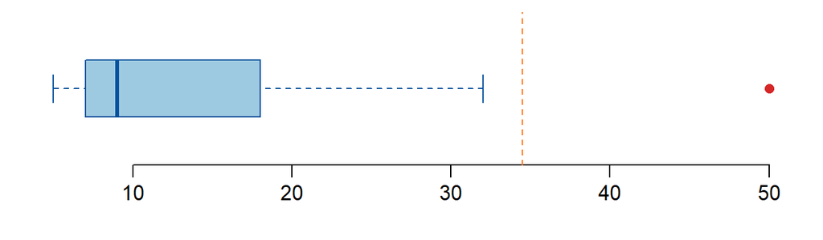

Bir mahalledeki dairelerin aylık aidatı (yüz TL) ($n = 13$):

$$29,\ 15,\ 23,\ 13,\ 10,\ 56,\ 20,\ 21,\ 15,\ 37,\ 24,\ 15,\ 24$$

Kartilleri $(n+1)p$ yöntemiyle bulunuz. Uç değer ölçütü: $Q_1 - 1.5 \cdot IQR$ altında ya da $Q_3 + 1.5 \cdot IQR$ üstünde kalan gözlemler.

- $Q_1$: $Q_3$:
- Alt sınır $Q_1 - 1.5 \cdot IQR$: Üst sınır $Q_3 + 1.5 \cdot IQR$:
- Uç değer sayısı:
- Kutu çiziminde üst bıyık hangi değerde biter?

Sıralı veri: $10,\ 13,\ 15,\ 15,\ 15,\ 20,\ 21,\ 23,\ 24,\ 24,\ 29,\ 37,\ 56$

- $(n+1) \times 0.25 = 3.5$ → $Q_1 = 15.00$; $\;(n+1) \times 0.75 = 10.5$ → $Q_3 = 26.50$
- $IQR = 26.50 - 15.00 = 11.50$
- Alt sınır: $15.00 - 1.5 \times 11.50 = -2.25$; üst sınır: $26.50 + 1.5 \times 11.50 = 43.75$

Alt sınırın altında gözlem yok. Üst sınırın üstünde yalnızca **56** var: **1** uç değer. 37 büyük görünse de sınırın altında kaldığı için uç değer **değildir**; bıyık, sınırın içindeki en büyük gözleme, yani **37** değerine kadar uzanır. Uç değer kutu çiziminde ayrı bir nokta olarak işaretlenir.

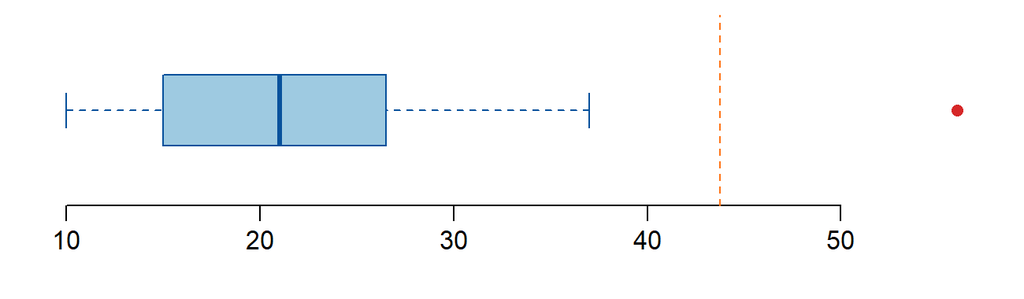

Bir kafede siparişlerin hazırlanma süresi (dakika) ($n = 14$):

$$15,\ 4,\ 5,\ 7,\ 10,\ 5,\ 14,\ 14,\ 6,\ 45,\ 5,\ 5,\ 26,\ 14$$

Kartilleri $(n+1)p$ yöntemiyle bulunuz. Uç değer ölçütü: $Q_1 - 1.5 \cdot IQR$ altında ya da $Q_3 + 1.5 \cdot IQR$ üstünde kalan gözlemler.

- $Q_1$: $Q_3$:
- Alt sınır $Q_1 - 1.5 \cdot IQR$: Üst sınır $Q_3 + 1.5 \cdot IQR$:
- Uç değer sayısı:
- Kutu çiziminde üst bıyık hangi değerde biter?

Sıralı veri: $4,\ 5,\ 5,\ 5,\ 5,\ 6,\ 7,\ 10,\ 14,\ 14,\ 14,\ 15,\ 26,\ 45$

- $(n+1) \times 0.25 = 3.75$ → $Q_1 = 5.00$; $\;(n+1) \times 0.75 = 11.25$ → $Q_3 = 14.25$
- $IQR = 14.25 - 5.00 = 9.25$
- Alt sınır: $5.00 - 1.5 \times 9.25 = -8.88$; üst sınır: $14.25 + 1.5 \times 9.25 = 28.12$

Alt sınırın altında gözlem yok. Üst sınırın üstünde yalnızca **45** var: **1** uç değer. 26 büyük görünse de sınırın altında kaldığı için uç değer **değildir**; bıyık, sınırın içindeki en büyük gözleme, yani **26** değerine kadar uzanır. Uç değer kutu çiziminde ayrı bir nokta olarak işaretlenir.

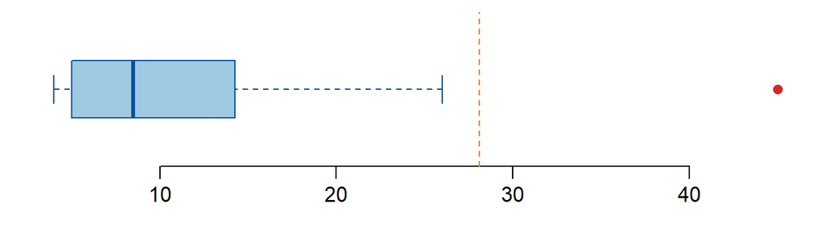

Bir kafede siparişlerin hazırlanma süresi (dakika) ($n = 13$):

$$13,\ 37,\ 14,\ 24,\ 7,\ 3,\ 5,\ 3,\ 11,\ 8,\ 10,\ 12,\ 13$$

Kartilleri $(n+1)p$ yöntemiyle bulunuz. Uç değer ölçütü: $Q_1 - 1.5 \cdot IQR$ altında ya da $Q_3 + 1.5 \cdot IQR$ üstünde kalan gözlemler.

- $Q_1$: $Q_3$:
- Alt sınır $Q_1 - 1.5 \cdot IQR$: Üst sınır $Q_3 + 1.5 \cdot IQR$:
- Uç değer sayısı:
- Kutu çiziminde üst bıyık hangi değerde biter?

Sıralı veri: $3,\ 3,\ 5,\ 7,\ 8,\ 10,\ 11,\ 12,\ 13,\ 13,\ 14,\ 24,\ 37$

- $(n+1) \times 0.25 = 3.5$ → $Q_1 = 6.00$; $\;(n+1) \times 0.75 = 10.5$ → $Q_3 = 13.50$
- $IQR = 13.50 - 6.00 = 7.50$
- Alt sınır: $6.00 - 1.5 \times 7.50 = -5.25$; üst sınır: $13.50 + 1.5 \times 7.50 = 24.75$

Alt sınırın altında gözlem yok. Üst sınırın üstünde yalnızca **37** var: **1** uç değer. 24 büyük görünse de sınırın altında kaldığı için uç değer **değildir**; bıyık, sınırın içindeki en büyük gözleme, yani **24** değerine kadar uzanır. Uç değer kutu çiziminde ayrı bir nokta olarak işaretlenir.

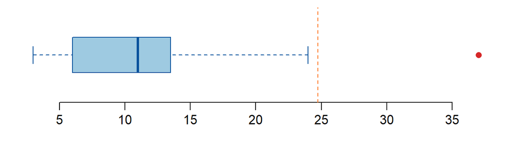

İki şubede müşterilerin bekleme süreleri (dakika), her grupta 60 gözlem.

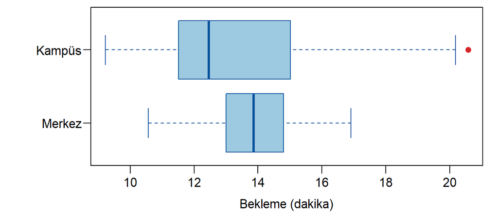

- Medyanı daha yüksek olan:
- Kartiller aralığı daha geniş olan:
- Sağa çarpık görünen:
- Uç değer bulunan:

|  | Medyan | $Q_1$ | $Q_3$ | IQR | Uç değer |
| --- | --- | --- | --- | --- | --- |
| Merkez | 13.9 | 13.0 | 14.8 | 1.8 | 0 |
| Kampüs | 12.5 | 11.5 | 15.0 | 3.5 | 1 |

- **Medyan:** kutunun içindeki çizgi. Merkez daha sağda.
- **IQR:** kutunun genişliği. Kampüs grubunun kutusu daha geniş: ortadaki yarı daha çok dağılmış.
- **Biçim:** Kampüs grubunda medyan kutunun sol tarafına yakın, sağ bıyık uzun ve uç değerler sağda: **sağa çarpık**. Öteki grupta medyan kutunun ortasında, bıyıklar benzer uzunlukta: yaklaşık simetrik.
- **Uç değer:** Kampüs grubunda 1 gözlem $Q_3 + 1.5 \cdot IQR$ sınırının üstünde.

Kutu çizimi medyan, yayılım ve çarpıklığı gruplar arasında hızla karşılaştırmayı sağlar. Ama dağılımın kaç tepeli olduğunu göstermez; bunun için histograma bakmak gerekir.

İki mahallede hanelerin aylık market harcaması (yüz TL), her grupta 60 gözlem.

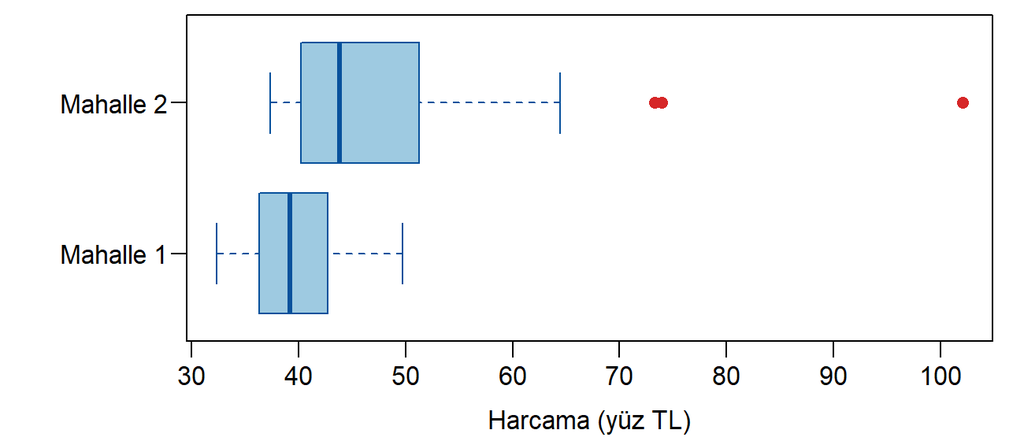

- Medyanı daha yüksek olan:
- Kartiller aralığı daha geniş olan:
- Sağa çarpık görünen:
- Uç değer bulunan:

|  | Medyan | $Q_1$ | $Q_3$ | IQR | Uç değer |
| --- | --- | --- | --- | --- | --- |
| Mahalle 1 | 39.2 | 36.3 | 42.8 | 6.4 | 0 |
| Mahalle 2 | 43.8 | 40.2 | 51.2 | 11.1 | 3 |

- **Medyan:** kutunun içindeki çizgi. Mahalle 2 daha sağda.
- **IQR:** kutunun genişliği. Mahalle 2 grubunun kutusu daha geniş: ortadaki yarı daha çok dağılmış.
- **Biçim:** Mahalle 2 grubunda medyan kutunun sol tarafına yakın, sağ bıyık uzun ve uç değerler sağda: **sağa çarpık**. Öteki grupta medyan kutunun ortasında, bıyıklar benzer uzunlukta: yaklaşık simetrik.
- **Uç değer:** Mahalle 2 grubunda 3 gözlem $Q_3 + 1.5 \cdot IQR$ sınırının üstünde.

Kutu çizimi medyan, yayılım ve çarpıklığı gruplar arasında hızla karşılaştırmayı sağlar. Ama dağılımın kaç tepeli olduğunu göstermez; bunun için histograma bakmak gerekir.

İki mahallede hanelerin aylık market harcaması (yüz TL), her grupta 60 gözlem.

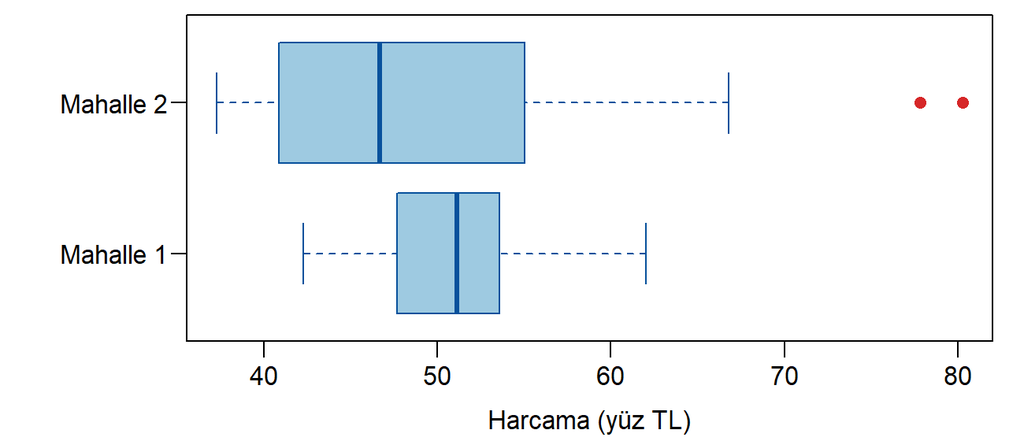

- Medyanı daha yüksek olan:
- Kartiller aralığı daha geniş olan:
- Sağa çarpık görünen:
- Uç değer bulunan:

|  | Medyan | $Q_1$ | $Q_3$ | IQR | Uç değer |
| --- | --- | --- | --- | --- | --- |
| Mahalle 1 | 51.1 | 47.7 | 53.6 | 5.9 | 0 |
| Mahalle 2 | 46.7 | 40.9 | 55.0 | 14.1 | 2 |

- **Medyan:** kutunun içindeki çizgi. Mahalle 1 daha sağda.
- **IQR:** kutunun genişliği. Mahalle 2 grubunun kutusu daha geniş: ortadaki yarı daha çok dağılmış.
- **Biçim:** Mahalle 2 grubunda medyan kutunun sol tarafına yakın, sağ bıyık uzun ve uç değerler sağda: **sağa çarpık**. Öteki grupta medyan kutunun ortasında, bıyıklar benzer uzunlukta: yaklaşık simetrik.
- **Uç değer:** Mahalle 2 grubunda 2 gözlem $Q_3 + 1.5 \cdot IQR$ sınırının üstünde.

Kutu çizimi medyan, yayılım ve çarpıklığı gruplar arasında hızla karşılaştırmayı sağlar. Ama dağılımın kaç tepeli olduğunu göstermez; bunun için histograma bakmak gerekir.

İki şubede müşterilerin bekleme süreleri (dakika), her grupta 60 gözlem.

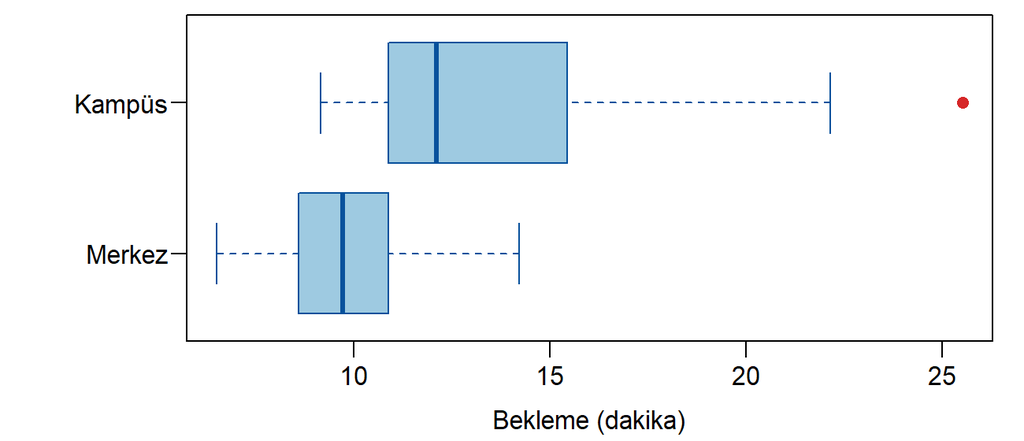

- Medyanı daha yüksek olan:
- Kartiller aralığı daha geniş olan:
- Sağa çarpık görünen:
- Uç değer bulunan:

|  | Medyan | $Q_1$ | $Q_3$ | IQR | Uç değer |
| --- | --- | --- | --- | --- | --- |
| Merkez | 9.7 | 8.6 | 10.9 | 2.3 | 0 |
| Kampüs | 12.1 | 10.9 | 15.4 | 4.6 | 1 |

- **Medyan:** kutunun içindeki çizgi. Kampüs daha sağda.
- **IQR:** kutunun genişliği. Kampüs grubunun kutusu daha geniş: ortadaki yarı daha çok dağılmış.
- **Biçim:** Kampüs grubunda medyan kutunun sol tarafına yakın, sağ bıyık uzun ve uç değerler sağda: **sağa çarpık**. Öteki grupta medyan kutunun ortasında, bıyıklar benzer uzunlukta: yaklaşık simetrik.
- **Uç değer:** Kampüs grubunda 1 gözlem $Q_3 + 1.5 \cdot IQR$ sınırının üstünde.

Kutu çizimi medyan, yayılım ve çarpıklığı gruplar arasında hızla karşılaştırmayı sağlar. Ama dağılımın kaç tepeli olduğunu göstermez; bunun için histograma bakmak gerekir.

### R çıktısını okuma

Bir hastane polikliniğinde 600 hastanın bekleme süresi (dakika) için R’da şu çıktılar elde edilmiştir:

```r
> mean(bekleme)
[1] 26.69
> sd(bekleme)
[1] 9.55
> quantile(bekleme, c(0.25, 0.50, 0.75), type = 6)
     25%      50%      75%
   20.00    24.95    32.00
```

- Kartiller aralığı (IQR):
- Değişkenlik katsayısı $CV$ (%, iki ondalık):
- Chebyshev’e göre gözlemlerin **en az %75**’i hangi aralıktadır? Alt: Üst:
- Kutu çiziminde üst uç değer sınırı $Q_3 + 1.5 \cdot IQR$:
- $IQR = Q_3 - Q_1 = 32.00 - 20.00 = 12.00$
- $CV = 100 \times s / \bar{x} = 100 \times 9.55 / 26.69 = 35.78$
- Chebyshev’de %75, $k = 2$ demektir ($1 - 1/2^2 = 0.75$): $\bar{x} \pm 2s = 26.69 \pm 2 \times 9.55$, yani 7.59 ile 45.79 arası.
- Üst sınır: $32.00 + 1.5 \times 12.00 = 50.00$

Ortalama (26.69) medyandan (24.95) büyük ve $Q_3$ medyana $Q_1$’den daha uzak: dağılım **sağa çarpık**. Süre ve kira gibi alt sınırı sıfır olan, üst sınırı olmayan değişkenlerde bu sık görülür. Chebyshev aralığının alt ucu veride hiç gözlem olmayan bir bölgeye düşüyor; sağa çarpık dağılımda “dışarıdaki” gözlemlerin hepsi sağ kuyruktadır.

Bir kargo firmasında 500 teslimatın süresi (saat) için R’da şu çıktılar elde edilmiştir:

```r
> mean(sure)
[1] 31.56
> sd(sure)
[1] 9.52
> quantile(sure, c(0.25, 0.50, 0.75), type = 6)
     25%      50%      75%
   24.70    30.40    37.27
```

- Kartiller aralığı (IQR):
- Değişkenlik katsayısı $CV$ (%, iki ondalık):
- Chebyshev’e göre gözlemlerin **en az %75**’i hangi aralıktadır? Alt: Üst:
- Kutu çiziminde üst uç değer sınırı $Q_3 + 1.5 \cdot IQR$:
- $IQR = Q_3 - Q_1 = 37.27 - 24.70 = 12.57$
- $CV = 100 \times s / \bar{x} = 100 \times 9.52 / 31.56 = 30.16$
- Chebyshev’de %75, $k = 2$ demektir ($1 - 1/2^2 = 0.75$): $\bar{x} \pm 2s = 31.56 \pm 2 \times 9.52$, yani 12.52 ile 50.60 arası.
- Üst sınır: $37.27 + 1.5 \times 12.57 = 56.13$

Ortalama (31.56) medyandan (30.40) büyük ve $Q_3$ medyana $Q_1$’den daha uzak: dağılım **sağa çarpık**. Süre ve kira gibi alt sınırı sıfır olan, üst sınırı olmayan değişkenlerde bu sık görülür.

Bir hastane polikliniğinde 600 hastanın bekleme süresi (dakika) için R’da şu çıktılar elde edilmiştir:

```r
> mean(bekleme)
[1] 26.65
> sd(bekleme)
[1] 9.17
> quantile(bekleme, c(0.25, 0.50, 0.75), type = 6)
     25%      50%      75%
   20.33    24.90    31.15
```

- Kartiller aralığı (IQR):
- Değişkenlik katsayısı $CV$ (%, iki ondalık):
- Chebyshev’e göre gözlemlerin **en az %75**’i hangi aralıktadır? Alt: Üst:
- Kutu çiziminde üst uç değer sınırı $Q_3 + 1.5 \cdot IQR$:
- $IQR = Q_3 - Q_1 = 31.15 - 20.33 = 10.82$
- $CV = 100 \times s / \bar{x} = 100 \times 9.17 / 26.65 = 34.41$
- Chebyshev’de %75, $k = 2$ demektir ($1 - 1/2^2 = 0.75$): $\bar{x} \pm 2s = 26.65 \pm 2 \times 9.17$, yani 8.31 ile 44.99 arası.
- Üst sınır: $31.15 + 1.5 \times 10.82 = 47.38$

Ortalama (26.65) medyandan (24.90) büyük ve $Q_3$ medyana $Q_1$’den daha uzak: dağılım **sağa çarpık**. Süre ve kira gibi alt sınırı sıfır olan, üst sınırı olmayan değişkenlerde bu sık görülür. Chebyshev aralığının alt ucu veride hiç gözlem olmayan bir bölgeye düşüyor; sağa çarpık dağılımda “dışarıdaki” gözlemlerin hepsi sağ kuyruktadır.

Bir kargo firmasında 500 teslimatın süresi (saat) için R’da şu çıktılar elde edilmiştir:

```r
> mean(sure)
[1] 30.92
> sd(sure)
[1] 9.32
> quantile(sure, c(0.25, 0.50, 0.75), type = 6)
     25%      50%      75%
   24.42    29.90    36.08
```

- Kartiller aralığı (IQR):
- Değişkenlik katsayısı $CV$ (%, iki ondalık):
- Chebyshev’e göre gözlemlerin **en az %75**’i hangi aralıktadır? Alt: Üst:
- Kutu çiziminde üst uç değer sınırı $Q_3 + 1.5 \cdot IQR$:
- $IQR = Q_3 - Q_1 = 36.08 - 24.42 = 11.66$
- $CV = 100 \times s / \bar{x} = 100 \times 9.32 / 30.92 = 30.14$
- Chebyshev’de %75, $k = 2$ demektir ($1 - 1/2^2 = 0.75$): $\bar{x} \pm 2s = 30.92 \pm 2 \times 9.32$, yani 12.28 ile 49.56 arası.
- Üst sınır: $36.08 + 1.5 \times 11.66 = 53.57$

Ortalama (30.92) medyandan (29.90) büyük ve $Q_3$ medyana $Q_1$’den daha uzak: dağılım **sağa çarpık**. Süre ve kira gibi alt sınırı sıfır olan, üst sınırı olmayan değişkenlerde bu sık görülür. Chebyshev aralığının alt ucu veride hiç gözlem olmayan bir bölgeye düşüyor; sağa çarpık dağılımda “dışarıdaki” gözlemlerin hepsi sağ kuyruktadır.

### Kovaryans ve korelasyon

Aşağıdaki serpilme çizimi için korelasyon katsayısı en yakın hangisidir?

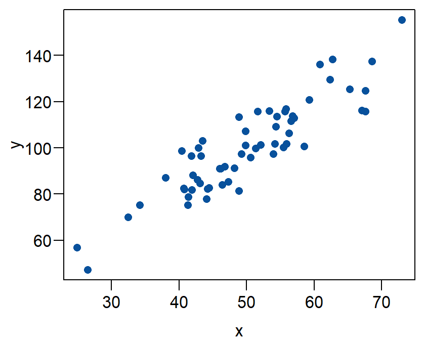

$-0.95$$-0.5$$0.2$$0.9$

Bu verinin korelasyon katsayısı $r = 0.90$. Noktalar yukarı doğru eğimli dar bir şerit oluşturuyor: güçlü pozitif doğrusal ilişki.

İşaret eğilimin yönünü, büyüklük noktaların bir doğru etrafında ne kadar sıkı toplandığını gösterir. Eğimin dikliği korelasyonu belirlemez: eksenlerin ölçeği değişince eğim görüntüsü değişir, $r$ değişmez.

Aşağıdaki serpilme çizimi için korelasyon katsayısı en yakın hangisidir?

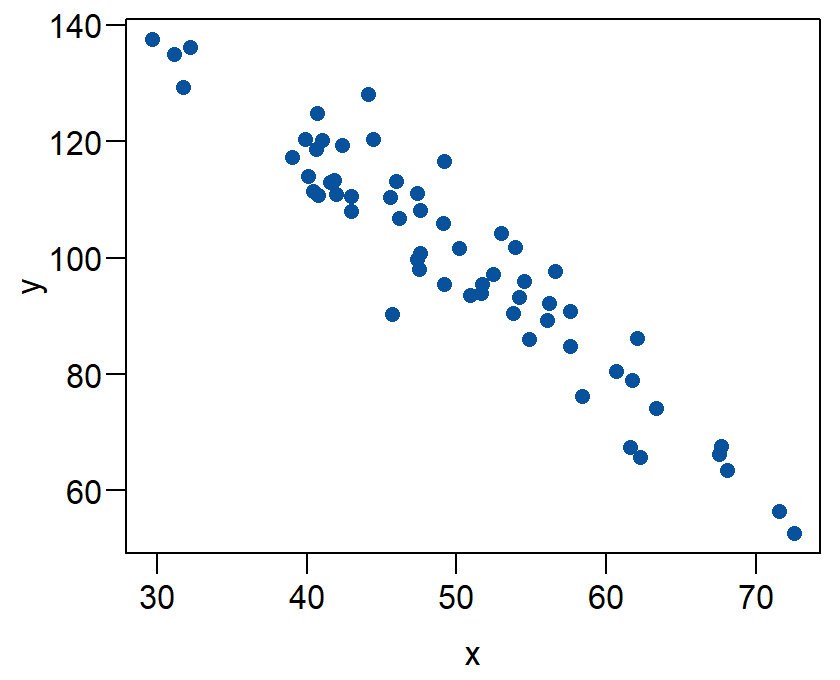

$-0.95$$-0.5$$0.2$$0.9$

Bu verinin korelasyon katsayısı $r = -0.95$. Noktalar aşağı doğru eğimli dar bir şerit oluşturuyor: güçlü negatif doğrusal ilişki.

İşaret eğilimin yönünü, büyüklük noktaların bir doğru etrafında ne kadar sıkı toplandığını gösterir. Eğimin dikliği korelasyonu belirlemez: eksenlerin ölçeği değişince eğim görüntüsü değişir, $r$ değişmez.

Aşağıdaki serpilme çizimi için korelasyon katsayısı en yakın hangisidir?

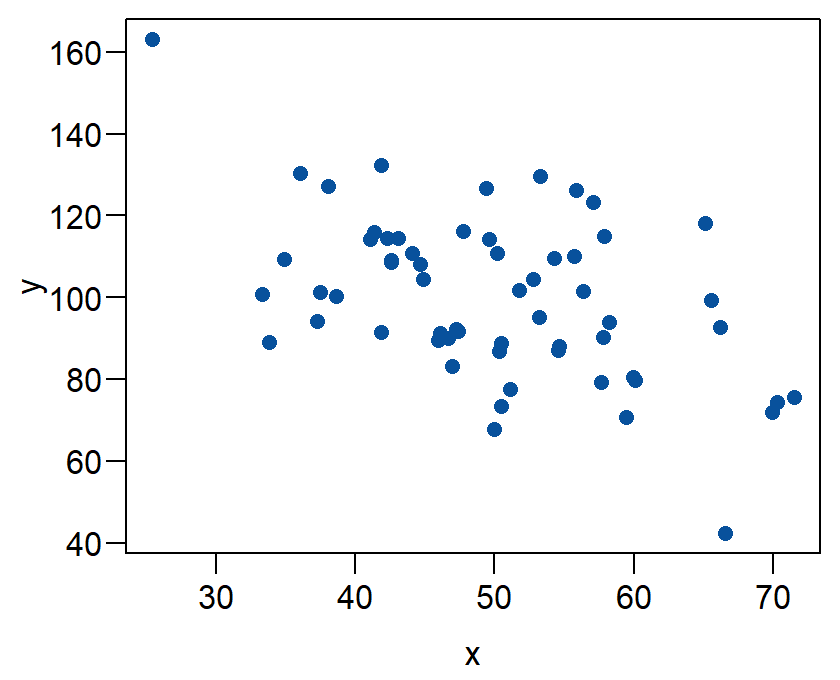

$-0.95$$-0.5$$0.2$$0.9$

Bu verinin korelasyon katsayısı $r = -0.50$. Aşağı doğru bir eğilim var ama noktalar geniş bir bulut oluşturuyor: orta güçte negatif ilişki.

İşaret eğilimin yönünü, büyüklük noktaların bir doğru etrafında ne kadar sıkı toplandığını gösterir. Eğimin dikliği korelasyonu belirlemez: eksenlerin ölçeği değişince eğim görüntüsü değişir, $r$ değişmez.

Aşağıdaki serpilme çizimi için korelasyon katsayısı en yakın hangisidir?

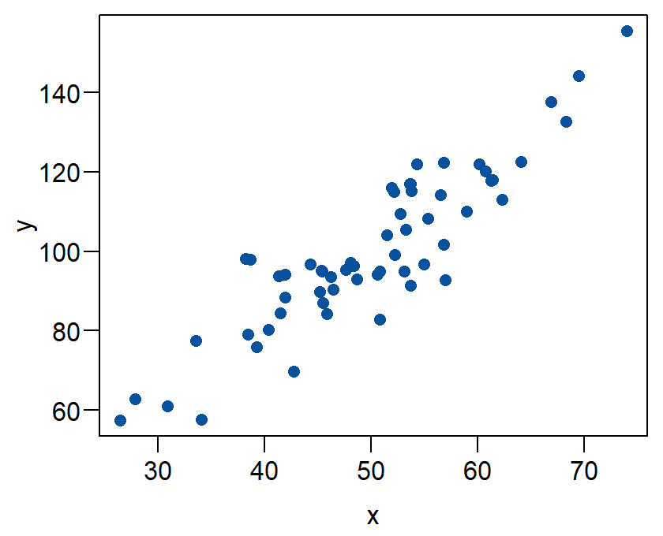

$-0.95$$-0.5$$0.2$$0.9$

Bu verinin korelasyon katsayısı $r = 0.90$. Noktalar yukarı doğru eğimli dar bir şerit oluşturuyor: güçlü pozitif doğrusal ilişki.

İşaret eğilimin yönünü, büyüklük noktaların bir doğru etrafında ne kadar sıkı toplandığını gösterir. Eğimin dikliği korelasyonu belirlemez: eksenlerin ölçeği değişince eğim görüntüsü değişir, $r$ değişmez.

Aşağıdaki serpilme çizimi için korelasyon katsayısı en yakın hangisidir?

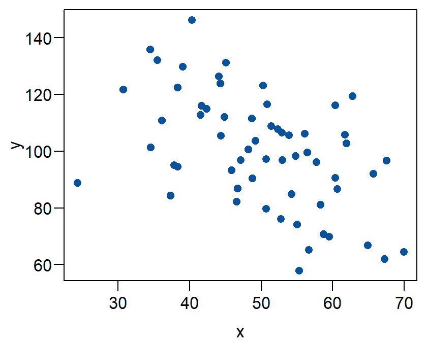

$-0.95$$-0.5$$0.2$$0.9$

Bu verinin korelasyon katsayısı $r = -0.50$. Aşağı doğru bir eğilim var ama noktalar geniş bir bulut oluşturuyor: orta güçte negatif ilişki.

İşaret eğilimin yönünü, büyüklük noktaların bir doğru etrafında ne kadar sıkı toplandığını gösterir. Eğimin dikliği korelasyonu belirlemez: eksenlerin ölçeği değişince eğim görüntüsü değişir, $r$ değişmez.

Aşağıdaki serpilme çizimi için korelasyon katsayısı en yakın hangisidir?

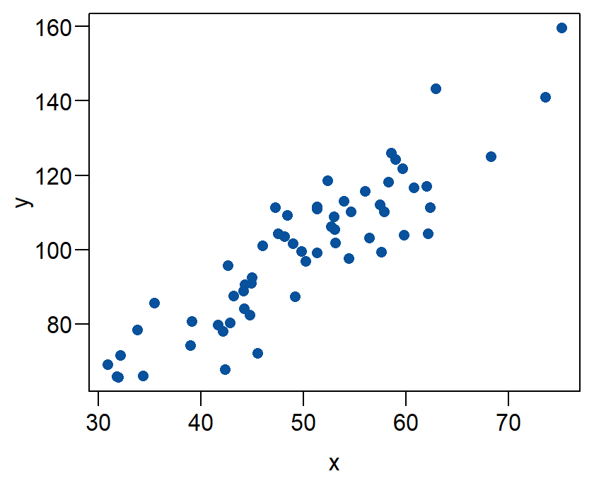

$-0.95$$-0.5$$0.2$$0.9$

Bu verinin korelasyon katsayısı $r = 0.90$. Noktalar yukarı doğru eğimli dar bir şerit oluşturuyor: güçlü pozitif doğrusal ilişki.

İşaret eğilimin yönünü, büyüklük noktaların bir doğru etrafında ne kadar sıkı toplandığını gösterir. Eğimin dikliği korelasyonu belirlemez: eksenlerin ölçeği değişince eğim görüntüsü değişir, $r$ değişmez.

Aşağıdaki serpilme çizimi için korelasyon katsayısı en yakın hangisidir?

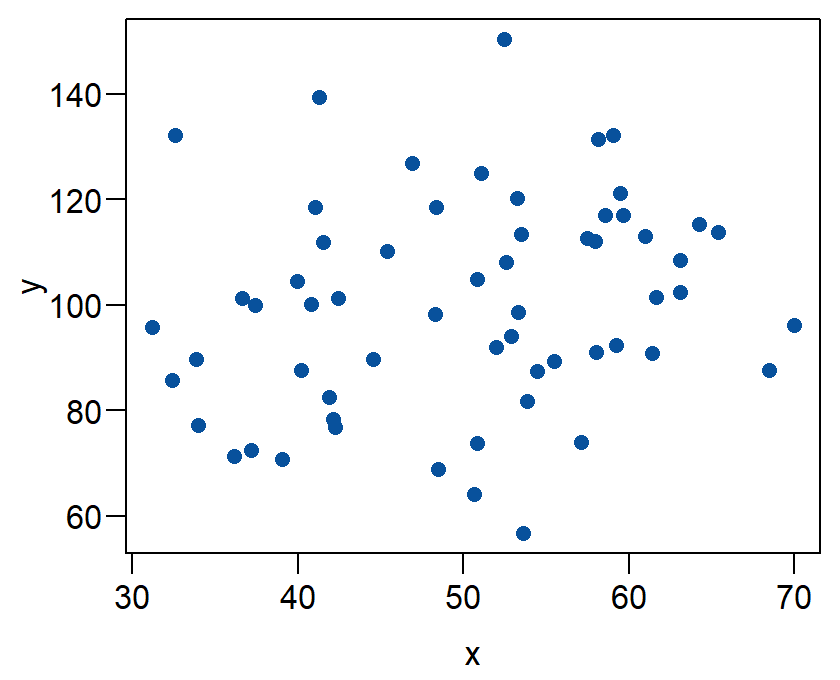

$-0.95$$-0.5$$0.2$$0.9$

Bu verinin korelasyon katsayısı $r = 0.20$. Belli belirsiz yukarı doğru bir eğilim var; noktalar neredeyse yuvarlak bir bulut: zayıf pozitif ilişki. Bu kadar zayıf bir korelasyonu gözle görmek zordur.

İşaret eğilimin yönünü, büyüklük noktaların bir doğru etrafında ne kadar sıkı toplandığını gösterir. Eğimin dikliği korelasyonu belirlemez: eksenlerin ölçeği değişince eğim görüntüsü değişir, $r$ değişmez.

Aşağıdaki serpilme çizimi için korelasyon katsayısı en yakın hangisidir?

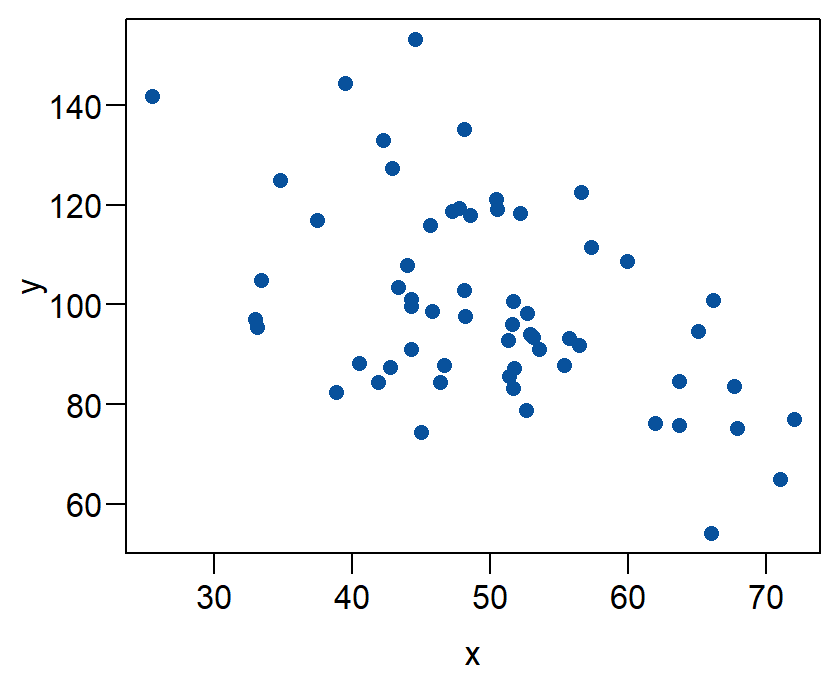

$-0.95$$-0.5$$0.2$$0.9$

Bu verinin korelasyon katsayısı $r = -0.50$. Aşağı doğru bir eğilim var ama noktalar geniş bir bulut oluşturuyor: orta güçte negatif ilişki.

İşaret eğilimin yönünü, büyüklük noktaların bir doğru etrafında ne kadar sıkı toplandığını gösterir. Eğimin dikliği korelasyonu belirlemez: eksenlerin ölçeği değişince eğim görüntüsü değişir, $r$ değişmez.

Altı öğrencinin haftalık çalışma süresi ($x$, saat) ve sınav notu ($y$):

|  | 1 | 2 | 3 | 4 | 5 | 6 |
| --- | --- | --- | --- | --- | --- | --- |
| $x$ | 13 | 5 | 9 | 11 | 4 | 6 |
| $y$ | 89 | 63 | 65 | 86 | 48 | 51 |

$\bar{x} = 8$, $\bar{y} = 67$, $s_x = 3.578$, $s_y = 17.216$.

- $\sum (x_i - \bar{x})(y_i - \bar{y})$:
- Örneklem kovaryansı $s_{xy}$ (iki ondalık):
- Korelasyon katsayısı $r$ (iki ondalık):
- $x$ saat yerine dakika cinsinden yazılırsa (her $x$ değeri 60 ile çarpılırsa) kovaryans (iki ondalık): korelasyon:

| $i$ | $x$ | $y$ | $x - \bar{x}$ | $y - \bar{y}$ | Çarpım |
| --- | --- | --- | --- | --- | --- |
| 1 | 13 | 89 | 5 | 22 | 110 |
| 2 | 5 | 63 | -3 | -4 | 12 |
| 3 | 9 | 65 | 1 | -2 | -2 |
| 4 | 11 | 86 | 3 | 19 | 57 |
| 5 | 4 | 48 | -4 | -19 | 76 |
| 6 | 6 | 51 | -2 | -16 | 32 |
| **Toplam** | **48** | **402** | **0** | **0** | **285** |

$$s_{xy} = \frac{285}{6 - 1} = 57.00, \qquad r = \frac{s_{xy}}{s_x s_y} = \frac{57.00}{3.578 \times 17.216} = 0.93$$

Pozitif ve güçlü bir doğrusal ilişki.

**Birim değişikliği.** Her $x$ 60 ile çarpılınca her sapma da 60 ile çarpılır; kovaryans $57.00 \times 60 = 3420.00$ olur. Aynı anda $s_x$ de 60 ile çarpıldığı için korelasyonda pay ve payda aynı oranda büyür: $r = 0.93$ **değişmez**. Kovaryansın büyüklüğü birime bağlıdır, korelasyonunki değil.

Altı ilçenin ortalama kira ($x$, bin TL) ve daire başına ortalama metrekare ($y$):

|  | 1 | 2 | 3 | 4 | 5 | 6 |
| --- | --- | --- | --- | --- | --- | --- |
| $x$ | 20 | 11 | 18 | 8 | 14 | 13 |
| $y$ | 92 | 104 | 85 | 117 | 100 | 108 |

$\bar{x} = 14$, $\bar{y} = 101$, $s_x = 4.427$, $s_y = 11.419$.

- $\sum (x_i - \bar{x})(y_i - \bar{y})$:
- Örneklem kovaryansı $s_{xy}$ (iki ondalık):
- Korelasyon katsayısı $r$ (iki ondalık):
- $x$ bin TL yerine TL cinsinden yazılırsa (her $x$ değeri 1000 ile çarpılırsa) kovaryans (iki ondalık): korelasyon:

| $i$ | $x$ | $y$ | $x - \bar{x}$ | $y - \bar{y}$ | Çarpım |
| --- | --- | --- | --- | --- | --- |
| 1 | 20 | 92 | 6 | -9 | -54 |
| 2 | 11 | 104 | -3 | 3 | -9 |
| 3 | 18 | 85 | 4 | -16 | -64 |
| 4 | 8 | 117 | -6 | 16 | -96 |
| 5 | 14 | 100 | 0 | -1 | 0 |
| 6 | 13 | 108 | -1 | 7 | -7 |
| **Toplam** | **84** | **606** | **0** | **0** | **-230** |

$$s_{xy} = \frac{-230}{6 - 1} = -46.00, \qquad r = \frac{s_{xy}}{s_x s_y} = \frac{-46.00}{4.427 \times 11.419} = -0.91$$

Negatif ve güçlü bir doğrusal ilişki.

**Birim değişikliği.** Her $x$ 1000 ile çarpılınca her sapma da 1000 ile çarpılır; kovaryans $-46.00 \times 1000 = -46000.00$ olur. Aynı anda $s_x$ de 1000 ile çarpıldığı için korelasyonda pay ve payda aynı oranda büyür: $r = -0.91$ **değişmez**. Kovaryansın büyüklüğü birime bağlıdır, korelasyonunki değil.

Altı ilçenin ortalama kira ($x$, bin TL) ve daire başına ortalama metrekare ($y$):

|  | 1 | 2 | 3 | 4 | 5 | 6 |
| --- | --- | --- | --- | --- | --- | --- |
| $x$ | 19 | 20 | 17 | 10 | 16 | 8 |
| $y$ | 88 | 92 | 91 | 113 | 97 | 113 |

$\bar{x} = 15$, $\bar{y} = 99$, $s_x = 4.899$, $s_y = 11.225$.

- $\sum (x_i - \bar{x})(y_i - \bar{y})$:
- Örneklem kovaryansı $s_{xy}$ (iki ondalık):
- Korelasyon katsayısı $r$ (iki ondalık):
- $x$ bin TL yerine TL cinsinden yazılırsa (her $x$ değeri 1000 ile çarpılırsa) kovaryans (iki ondalık): korelasyon:

| $i$ | $x$ | $y$ | $x - \bar{x}$ | $y - \bar{y}$ | Çarpım |
| --- | --- | --- | --- | --- | --- |
| 1 | 19 | 88 | 4 | -11 | -44 |
| 2 | 20 | 92 | 5 | -7 | -35 |
| 3 | 17 | 91 | 2 | -8 | -16 |
| 4 | 10 | 113 | -5 | 14 | -70 |
| 5 | 16 | 97 | 1 | -2 | -2 |
| 6 | 8 | 113 | -7 | 14 | -98 |
| **Toplam** | **90** | **594** | **0** | **0** | **-265** |

$$s_{xy} = \frac{-265}{6 - 1} = -53.00, \qquad r = \frac{s_{xy}}{s_x s_y} = \frac{-53.00}{4.899 \times 11.225} = -0.96$$

Negatif ve güçlü bir doğrusal ilişki.

**Birim değişikliği.** Her $x$ 1000 ile çarpılınca her sapma da 1000 ile çarpılır; kovaryans $-53.00 \times 1000 = -53000.00$ olur. Aynı anda $s_x$ de 1000 ile çarpıldığı için korelasyonda pay ve payda aynı oranda büyür: $r = -0.96$ **değişmez**. Kovaryansın büyüklüğü birime bağlıdır, korelasyonunki değil.

Altı firmanın reklam harcaması ($x$, milyon TL) ve satışları ($y$, milyon TL):

|  | 1 | 2 | 3 | 4 | 5 | 6 |
| --- | --- | --- | --- | --- | --- | --- |
| $x$ | 3 | 6 | 4 | 7 | 8 | 2 |
| $y$ | 42 | 46 | 10 | 40 | 41 | 7 |

$\bar{x} = 5$, $\bar{y} = 31$, $s_x = 2.366$, $s_y = 17.573$.

- $\sum (x_i - \bar{x})(y_i - \bar{y})$:
- Örneklem kovaryansı $s_{xy}$ (iki ondalık):
- Korelasyon katsayısı $r$ (iki ondalık):
- $x$ milyon TL yerine bin TL cinsinden yazılırsa (her $x$ değeri 1000 ile çarpılırsa) kovaryans (iki ondalık): korelasyon:

| $i$ | $x$ | $y$ | $x - \bar{x}$ | $y - \bar{y}$ | Çarpım |
| --- | --- | --- | --- | --- | --- |
| 1 | 3 | 42 | -2 | 11 | -22 |
| 2 | 6 | 46 | 1 | 15 | 15 |
| 3 | 4 | 10 | -1 | -21 | 21 |
| 4 | 7 | 40 | 2 | 9 | 18 |
| 5 | 8 | 41 | 3 | 10 | 30 |
| 6 | 2 | 7 | -3 | -24 | 72 |
| **Toplam** | **30** | **186** | **0** | **0** | **134** |

$$s_{xy} = \frac{134}{6 - 1} = 26.80, \qquad r = \frac{s_{xy}}{s_x s_y} = \frac{26.80}{2.366 \times 17.573} = 0.64$$

Pozitif ve orta güçte bir doğrusal ilişki.

**Birim değişikliği.** Her $x$ 1000 ile çarpılınca her sapma da 1000 ile çarpılır; kovaryans $26.80 \times 1000 = 26800.00$ olur. Aynı anda $s_x$ de 1000 ile çarpıldığı için korelasyonda pay ve payda aynı oranda büyür: $r = 0.64$ **değişmez**. Kovaryansın büyüklüğü birime bağlıdır, korelasyonunki değil.

> Öğrenciler arasında kütüphanede geçirilen süre ile ders dışı kursa harcanan para arasında pozitif korelasyon var.

Bu korelasyonun nedensel bir etkiyi göstermesi gerekmez. Aşağıdakilerden hangisi en olası açıklamadır?

Ortak neden: üçüncü bir değişken ikisini birlikte etkiliyorTers nedensellik: etki beklenenin tersi yönde olabilirOrtak zaman eğilimi: iki seri zamanla tek yönde hareket ediyor

**Ortak neden: üçüncü bir değişken ikisini birlikte etkiliyor.** Motivasyonu ve ailesinin olanakları yüksek öğrenciler hem kütüphanede daha çok zaman geçirir hem kursa daha çok harcar.

Korelasyon iki değişkenin birlikte hareket ettiğini söyler, neden birlikte hareket ettiklerini söylemez. Bir senaryoda birden fazla açıklama birlikte geçerli olabilir. Nedensel bir soruyu yanıtlamak için rassal atamalı bir deney ya da İstatistik II’de ve ekonometride göreceğiniz daha ileri yöntemler gerekir.

> Türkiye’de 2005-2024 döneminde yıllık kahve dükkânı sayısı ile üniversite mezunu sayısı arasındaki korelasyon 0.93.

Bu korelasyonun nedensel bir etkiyi göstermesi gerekmez. Aşağıdakilerden hangisi en olası açıklamadır?

Ortak neden: üçüncü bir değişken ikisini birlikte etkiliyorTers nedensellik: etki beklenenin tersi yönde olabilirOrtak zaman eğilimi: iki seri zamanla tek yönde hareket ediyor

**Ortak zaman eğilimi: iki seri zamanla tek yönde hareket ediyor.** İkisi de dönem boyunca kentleşme ve gelir artışıyla birlikte düzenli arttı; aralarında doğrudan bir bağ olması gerekmez.

Korelasyon iki değişkenin birlikte hareket ettiğini söyler, neden birlikte hareket ettiklerini söylemez. Bir senaryoda birden fazla açıklama birlikte geçerli olabilir. Nedensel bir soruyu yanıtlamak için rassal atamalı bir deney ya da İstatistik II’de ve ekonometride göreceğiniz daha ileri yöntemler gerekir.

> Bir ülkede 2000-2023 döneminde internet kullanıcı oranı ile tarımda çalışanların oranı arasındaki korelasyon -0.92.

Bu korelasyonun nedensel bir etkiyi göstermesi gerekmez. Aşağıdakilerden hangisi en olası açıklamadır?

Ortak neden: üçüncü bir değişken ikisini birlikte etkiliyorTers nedensellik: etki beklenenin tersi yönde olabilirOrtak zaman eğilimi: iki seri zamanla tek yönde hareket ediyor

**Ortak zaman eğilimi: iki seri zamanla tek yönde hareket ediyor.** Biri düzenli artarken öteki düzenli azaldı; zaman içinde tek yönde ilerleyen iki seri güçlü (negatif) korelasyon gösterir.

Korelasyon iki değişkenin birlikte hareket ettiğini söyler, neden birlikte hareket ettiklerini söylemez. Bir senaryoda birden fazla açıklama birlikte geçerli olabilir. Nedensel bir soruyu yanıtlamak için rassal atamalı bir deney ya da İstatistik II’de ve ekonometride göreceğiniz daha ileri yöntemler gerekir.

> Hastaneler arasında yatak başına düşen doktor sayısı ile hasta ölüm oranı arasında pozitif korelasyon var.

Bu korelasyonun nedensel bir etkiyi göstermesi gerekmez. Aşağıdakilerden hangisi en olası açıklamadır?

Ortak neden: üçüncü bir değişken ikisini birlikte etkiliyorTers nedensellik: etki beklenenin tersi yönde olabilirOrtak zaman eğilimi: iki seri zamanla tek yönde hareket ediyor

**Ters nedensellik: etki beklenenin tersi yönde olabilir.** Ağır hastaların gittiği hastanelere daha çok doktor atanır: ağır hasta yükü doktor sayısını artırıyor olabilir.

Korelasyon iki değişkenin birlikte hareket ettiğini söyler, neden birlikte hareket ettiklerini söylemez. Bir senaryoda birden fazla açıklama birlikte geçerli olabilir. Nedensel bir soruyu yanıtlamak için rassal atamalı bir deney ya da İstatistik II’de ve ekonometride göreceğiniz daha ileri yöntemler gerekir.

> Bir ülkede 2000-2023 döneminde internet kullanıcı oranı ile tarımda çalışanların oranı arasındaki korelasyon -0.92.

Bu korelasyonun nedensel bir etkiyi göstermesi gerekmez. Aşağıdakilerden hangisi en olası açıklamadır?

Ortak neden: üçüncü bir değişken ikisini birlikte etkiliyorTers nedensellik: etki beklenenin tersi yönde olabilirOrtak zaman eğilimi: iki seri zamanla tek yönde hareket ediyor

**Ortak zaman eğilimi: iki seri zamanla tek yönde hareket ediyor.** Biri düzenli artarken öteki düzenli azaldı; zaman içinde tek yönde ilerleyen iki seri güçlü (negatif) korelasyon gösterir.

Korelasyon iki değişkenin birlikte hareket ettiğini söyler, neden birlikte hareket ettiklerini söylemez. Bir senaryoda birden fazla açıklama birlikte geçerli olabilir. Nedensel bir soruyu yanıtlamak için rassal atamalı bir deney ya da İstatistik II’de ve ekonometride göreceğiniz daha ileri yöntemler gerekir.

> Bir ülkede 1990-2020 döneminde yıllık cep telefonu abone sayısı ile ortalama yaşam beklentisi arasındaki korelasyon 0.95.

Bu korelasyonun nedensel bir etkiyi göstermesi gerekmez. Aşağıdakilerden hangisi en olası açıklamadır?

Ortak neden: üçüncü bir değişken ikisini birlikte etkiliyorTers nedensellik: etki beklenenin tersi yönde olabilirOrtak zaman eğilimi: iki seri zamanla tek yönde hareket ediyor

**Ortak zaman eğilimi: iki seri zamanla tek yönde hareket ediyor.** İki değişken de bu dönemde başka nedenlerle düzenli olarak arttı; zamanla birlikte yükselen hemen her iki seri güçlü korelasyon gösterir.

Korelasyon iki değişkenin birlikte hareket ettiğini söyler, neden birlikte hareket ettiklerini söylemez. Bir senaryoda birden fazla açıklama birlikte geçerli olabilir. Nedensel bir soruyu yanıtlamak için rassal atamalı bir deney ya da İstatistik II’de ve ekonometride göreceğiniz daha ileri yöntemler gerekir.

> Bir ülkede 2000-2023 döneminde internet kullanıcı oranı ile tarımda çalışanların oranı arasındaki korelasyon -0.92.

Bu korelasyonun nedensel bir etkiyi göstermesi gerekmez. Aşağıdakilerden hangisi en olası açıklamadır?

Ortak neden: üçüncü bir değişken ikisini birlikte etkiliyorTers nedensellik: etki beklenenin tersi yönde olabilirOrtak zaman eğilimi: iki seri zamanla tek yönde hareket ediyor

**Ortak zaman eğilimi: iki seri zamanla tek yönde hareket ediyor.** Biri düzenli artarken öteki düzenli azaldı; zaman içinde tek yönde ilerleyen iki seri güçlü (negatif) korelasyon gösterir.

Korelasyon iki değişkenin birlikte hareket ettiğini söyler, neden birlikte hareket ettiklerini söylemez. Bir senaryoda birden fazla açıklama birlikte geçerli olabilir. Nedensel bir soruyu yanıtlamak için rassal atamalı bir deney ya da İstatistik II’de ve ekonometride göreceğiniz daha ileri yöntemler gerekir.

> İller arasında eczane sayısı ile yıllık ölüm sayısı arasında güçlü pozitif korelasyon var.

Bu korelasyonun nedensel bir etkiyi göstermesi gerekmez. Aşağıdakilerden hangisi en olası açıklamadır?

Ortak neden: üçüncü bir değişken ikisini birlikte etkiliyorTers nedensellik: etki beklenenin tersi yönde olabilirOrtak zaman eğilimi: iki seri zamanla tek yönde hareket ediyor

**Ortak neden: üçüncü bir değişken ikisini birlikte etkiliyor.** Nüfusu kalabalık iller hem daha çok eczaneye hem daha çok ölüme sahiptir; ortak neden nüfustur.

Korelasyon iki değişkenin birlikte hareket ettiğini söyler, neden birlikte hareket ettiklerini söylemez. Bir senaryoda birden fazla açıklama birlikte geçerli olabilir. Nedensel bir soruyu yanıtlamak için rassal atamalı bir deney ya da İstatistik II’de ve ekonometride göreceğiniz daha ileri yöntemler gerekir.

## Yanılgıları yakalama

Aşağıdaki ifadelerden **doğru olanların hepsini** işaretleyiniz.

Chebyshev teoremi dağılımın biçiminden bağımsız olarak geçerlidir.Kartiller aralığı (IQR), uç değerlere aralıktan daha az duyarlıdır.Chebyshev teoremine göre gözlemlerin yaklaşık %75’i ortalamadan en çok 2 standart sapma uzaktadır.Varyans negatif olabilir.Medyan, uç değerlere ortalamadan daha az duyarlıdır.

Her ifadenin değerlendirmesi aşağıdadır. Yanlış bir ifadeyi işaretlediyseniz neden yanlış olduğunu kendi cümlelerinizle yazmayı deneyin.

- **Doğru.** Teoremin gücü de zayıflığı da budur: her dağılımda geçerli, ama gevşek bir alt sınır verir.
- **Doğru.** IQR ortadaki yarıya bakar; aralık ise tam olarak uçtaki iki gözleme.
- **Yanlış.** Teorem “yaklaşık” değil “en az” der; gerçek oran daha yüksek olabilir.
- **Yanlış.** Sapmaların kareleri toplandığı için varyans hiçbir zaman negatif olamaz.
- **Doğru.** Medyan sıralamaya dayanır; uç değerin büyüklüğü onu etkilemez.

Aşağıdaki ifadelerden **doğru olanların hepsini** işaretleyiniz.

Çok sayıda öğrencinin girdiği bir sınavda öğrencilerin %70’inin medyandan yüksek not alması mümkündür.Kartiller aralığı (IQR), uç değerlere aralıktan daha az duyarlıdır.Chebyshev teoremi dağılımın biçiminden bağımsız olarak geçerlidir.Varyans verinin birimiyle aynı birimde ölçülür.Aralık, uç değerlerden etkilenmeyen bir değişkenlik ölçüsüdür.

Her ifadenin değerlendirmesi aşağıdadır. Yanlış bir ifadeyi işaretlediyseniz neden yanlış olduğunu kendi cümlelerinizle yazmayı deneyin.

- **Yanlış.** Medyan tanımı gereği gözlemlerin yarısını altında, yarısını üstünde bırakır.
- **Doğru.** IQR ortadaki yarıya bakar; aralık ise tam olarak uçtaki iki gözleme.
- **Doğru.** Teoremin gücü de zayıflığı da budur: her dağılımda geçerli, ama gevşek bir alt sınır verir.
- **Yanlış.** Varyansın birimi verinin biriminin karesidir (TL²); verinin biriminde olan standart sapmadır.
- **Yanlış.** Aralık yalnızca en büyük ve en küçük gözleme bakar; tek bir uç değer onu değiştirir.

Aşağıdaki ifadelerden **doğru olanların hepsini** işaretleyiniz.

Aralık, uç değerlerden etkilenmeyen bir değişkenlik ölçüsüdür.İki veri kümesinin aralığı eşitse standart sapmaları da eşittir.Kartiller aralığı (IQR), uç değerlere aralıktan daha az duyarlıdır.Chebyshev teoremi dağılımın biçiminden bağımsız olarak geçerlidir.Kutu çizimi dağılımın kaç tepeli olduğu hakkında bilgi vermez.

Her ifadenin değerlendirmesi aşağıdadır. Yanlış bir ifadeyi işaretlediyseniz neden yanlış olduğunu kendi cümlelerinizle yazmayı deneyin.

- **Yanlış.** Aralık yalnızca en büyük ve en küçük gözleme bakar; tek bir uç değer onu değiştirir.
- **Yanlış.** Aralık yalnızca uçlara bakar; gözlemlerin merkezde mi uçlarda mı toplandığı standart sapmayı değiştirir.
- **Doğru.** IQR ortadaki yarıya bakar; aralık ise tam olarak uçtaki iki gözleme.
- **Doğru.** Teoremin gücü de zayıflığı da budur: her dağılımda geçerli, ama gevşek bir alt sınır verir.
- **Doğru.** İki tepeli ve tek tepeli dağılımlar aynı kutu çizimini verebilir; tepe sayısı histogramdan görülür.

Aşağıdaki ifadelerden **doğru olanların hepsini** işaretleyiniz.

İki veri kümesinin aralığı eşitse standart sapmaları da eşittir.Kutu çizimi dağılımın kaç tepeli olduğu hakkında bilgi vermez.Medyan, uç değerlere ortalamadan daha az duyarlıdır.Çok sayıda öğrencinin girdiği bir sınavda öğrencilerin %70’inin ortalamadan yüksek not alması mümkündür.Varyans verinin birimiyle aynı birimde ölçülür.

Her ifadenin değerlendirmesi aşağıdadır. Yanlış bir ifadeyi işaretlediyseniz neden yanlış olduğunu kendi cümlelerinizle yazmayı deneyin.

- **Yanlış.** Aralık yalnızca uçlara bakar; gözlemlerin merkezde mi uçlarda mı toplandığı standart sapmayı değiştirir.
- **Doğru.** İki tepeli ve tek tepeli dağılımlar aynı kutu çizimini verebilir; tepe sayısı histogramdan görülür.
- **Doğru.** Medyan sıralamaya dayanır; uç değerin büyüklüğü onu etkilemez.
- **Doğru.** Dağılım sola çarpıksa (az sayıda çok düşük not) ortalama medyanın altına iner ve öğrencilerin yarıdan fazlası ortalamanın üstünde kalabilir.
- **Yanlış.** Varyansın birimi verinin biriminin karesidir (TL²); verinin biriminde olan standart sapmadır.

Aşağıdaki ifadelerden **doğru olanların hepsini** işaretleyiniz.

Çok sayıda öğrencinin girdiği bir sınavda öğrencilerin %70’inin ortalamadan yüksek not alması mümkündür.İki veri kümesinin aralığı eşitse standart sapmaları da eşittir.Varyans verinin birimiyle aynı birimde ölçülür.Kartiller aralığı (IQR), uç değerlere aralıktan daha az duyarlıdır.Çarpıklık katsayısı pozitifse medyan ortalamadan büyüktür.

Her ifadenin değerlendirmesi aşağıdadır. Yanlış bir ifadeyi işaretlediyseniz neden yanlış olduğunu kendi cümlelerinizle yazmayı deneyin.

- **Doğru.** Dağılım sola çarpıksa (az sayıda çok düşük not) ortalama medyanın altına iner ve öğrencilerin yarıdan fazlası ortalamanın üstünde kalabilir.
- **Yanlış.** Aralık yalnızca uçlara bakar; gözlemlerin merkezde mi uçlarda mı toplandığı standart sapmayı değiştirir.
- **Yanlış.** Varyansın birimi verinin biriminin karesidir (TL²); verinin biriminde olan standart sapmadır.
- **Doğru.** IQR ortadaki yarıya bakar; aralık ise tam olarak uçtaki iki gözleme.
- **Yanlış.** Pozitif çarpıklık uzun sağ kuyruk demektir; sağdaki büyük değerler ortalamayı medyanın üstüne çeker.

Aşağıdaki ifadelerden **doğru olanların hepsini** işaretleyiniz.

Aralık, uç değerlerden etkilenmeyen bir değişkenlik ölçüsüdür.Medyan, uç değerlere ortalamadan daha az duyarlıdır.Çok sayıda öğrencinin girdiği bir sınavda öğrencilerin %70’inin ortalamadan yüksek not alması mümkündür.Chebyshev teoremi dağılımın biçiminden bağımsız olarak geçerlidir.Çarpıklık katsayısı pozitifse medyan ortalamadan büyüktür.

Her ifadenin değerlendirmesi aşağıdadır. Yanlış bir ifadeyi işaretlediyseniz neden yanlış olduğunu kendi cümlelerinizle yazmayı deneyin.

- **Yanlış.** Aralık yalnızca en büyük ve en küçük gözleme bakar; tek bir uç değer onu değiştirir.
- **Doğru.** Medyan sıralamaya dayanır; uç değerin büyüklüğü onu etkilemez.
- **Doğru.** Dağılım sola çarpıksa (az sayıda çok düşük not) ortalama medyanın altına iner ve öğrencilerin yarıdan fazlası ortalamanın üstünde kalabilir.
- **Doğru.** Teoremin gücü de zayıflığı da budur: her dağılımda geçerli, ama gevşek bir alt sınır verir.
- **Yanlış.** Pozitif çarpıklık uzun sağ kuyruk demektir; sağdaki büyük değerler ortalamayı medyanın üstüne çeker.

Aşağıdaki ifadelerden **doğru olanların hepsini** işaretleyiniz.

Çok sayıda öğrencinin girdiği bir sınavda öğrencilerin %70’inin ortalamadan yüksek not alması mümkündür.İki veri kümesinin aralığı eşitse standart sapmaları da eşittir.Aralık, uç değerlerden etkilenmeyen bir değişkenlik ölçüsüdür.Chebyshev teoremi dağılımın biçiminden bağımsız olarak geçerlidir.Çok sayıda öğrencinin girdiği bir sınavda öğrencilerin %70’inin medyandan yüksek not alması mümkündür.

Her ifadenin değerlendirmesi aşağıdadır. Yanlış bir ifadeyi işaretlediyseniz neden yanlış olduğunu kendi cümlelerinizle yazmayı deneyin.

- **Doğru.** Dağılım sola çarpıksa (az sayıda çok düşük not) ortalama medyanın altına iner ve öğrencilerin yarıdan fazlası ortalamanın üstünde kalabilir.
- **Yanlış.** Aralık yalnızca uçlara bakar; gözlemlerin merkezde mi uçlarda mı toplandığı standart sapmayı değiştirir.
- **Yanlış.** Aralık yalnızca en büyük ve en küçük gözleme bakar; tek bir uç değer onu değiştirir.
- **Doğru.** Teoremin gücü de zayıflığı da budur: her dağılımda geçerli, ama gevşek bir alt sınır verir.
- **Yanlış.** Medyan tanımı gereği gözlemlerin yarısını altında, yarısını üstünde bırakır.

Aşağıdaki ifadelerden **doğru olanların hepsini** işaretleyiniz.

Varyans verinin birimiyle aynı birimde ölçülür.Chebyshev teoremine göre gözlemlerin yaklaşık %75’i ortalamadan en çok 2 standart sapma uzaktadır.Kartiller aralığı (IQR), uç değerlere aralıktan daha az duyarlıdır.Bir veri kümesinin standart sapması 0 ise bütün gözlemler birbirine eşittir.Standart sapmaları farklı birimde ölçülen iki değişkenden standart sapması büyük olan daha değişkendir.

Her ifadenin değerlendirmesi aşağıdadır. Yanlış bir ifadeyi işaretlediyseniz neden yanlış olduğunu kendi cümlelerinizle yazmayı deneyin.

- **Yanlış.** Varyansın birimi verinin biriminin karesidir (TL²); verinin biriminde olan standart sapmadır.
- **Yanlış.** Teorem “yaklaşık” değil “en az” der; gerçek oran daha yüksek olabilir.
- **Doğru.** IQR ortadaki yarıya bakar; aralık ise tam olarak uçtaki iki gözleme.
- **Doğru.** Sapma kareleri toplamı ancak her sapma sıfırsa sıfır olur.
- **Yanlış.** Farklı birimlerdeki standart sapmalar doğrudan karşılaştırılamaz; değişkenlik katsayısı kullanılır.

Kovaryans ve korelasyon katsayısı hakkında aşağıdaki ifadelerden **doğru olanların hepsini** işaretleyiniz.

Kovaryansın büyük çıkması ilişkinin güçlü olduğu anlamına gelir.Korelasyon katsayısı yalnızca pozitif değerler alabilir.Korelasyon katsayısı $-1$ ile $1$ arasında değer alır.Korelasyon katsayısının sıfıra yakın olması doğrusal olmayan güçlü bir ilişkinin varlığını dışlamaz.Korelasyon katsayısı birimsizdir, değişkenlerin ölçü birimlerine bağlı değildir.

Bu soruda sık yapılan hataların arkasındaki üç ayrım şudur.

**Kovaryans ile korelasyon.** Kovaryans iki değişkenin birimlerinin çarpımı cinsinden ölçülür ve herhangi bir değer alabilir. Bu yüzden büyüklüğü tek başına ilişkinin gücü hakkında bilgi vermez, yalnızca işareti yorumlanır. Korelasyon katsayısı kovaryansın standart sapmaların çarpımına bölünmüş halidir.

$$r = \frac{s_{xy}}{s_x s_y}$$

Bu bölme birimleri götürür ve katsayıyı $-1$ ile $1$ arasına sıkıştırır. Ölçü birimi değişikliği hem kovaryansı hem standart sapmaları aynı oranda etkilediği için korelasyon katsayısı değişmez.

**Sıfır korelasyon ile bağımsızlık.** Korelasyon yalnızca **doğrusal** ilişkiyi ölçer. $y = x^2$ gibi güçlü ama simetrik bir ilişkide korelasyon sıfıra çok yakın çıkabilir. Sıfır korelasyon bağımsızlık anlamına gelmez.

**Korelasyon ile nedensellik.** İki değişkenin birlikte hareket etmesi birinin diğerine yol açtığını göstermez. Aradaki ilişki üçüncü bir değişkenden, ters yönlü bir etkiden ya da rastlantıdan kaynaklanıyor olabilir.

Bir de şu var. Aynı korelasyon katsayısını veren veri kümelerinin serpilme diyagramları birbirinden tamamen farklı olabilir. Derste gördüğümüz Anscombe’un dört veri kümesi bunu gösterir. Bu yüzden korelasyon katsayısını hesaplamadan önce mutlaka serpilme diyagramına bakılmalıdır.

Bu denemede işaretlenmesi gereken ifadeler aşağıda belirtilmiştir.

- **Yanlış.**
- **Yanlış.**
- **Doğru.**
- **Doğru.**
- **Doğru.**

Kovaryans ve korelasyon katsayısı hakkında aşağıdaki ifadelerden **doğru olanların hepsini** işaretleyiniz.

Her iki değişken de sabit bir sayıyla çarpılırsa korelasyon katsayısı değişmez.Korelasyon katsayısının büyük olması değişkenler arasında nedensellik bulunduğunu gösterir.Kovaryansın işareti ile korelasyon katsayısının işareti aynıdır.Korelasyon katsayısı $-1$ ile $1$ arasında değer alır.Korelasyon katsayısı yalnızca pozitif değerler alabilir.

Bu soruda sık yapılan hataların arkasındaki üç ayrım şudur.

**Kovaryans ile korelasyon.** Kovaryans iki değişkenin birimlerinin çarpımı cinsinden ölçülür ve herhangi bir değer alabilir. Bu yüzden büyüklüğü tek başına ilişkinin gücü hakkında bilgi vermez, yalnızca işareti yorumlanır. Korelasyon katsayısı kovaryansın standart sapmaların çarpımına bölünmüş halidir.

$$r = \frac{s_{xy}}{s_x s_y}$$

Bu bölme birimleri götürür ve katsayıyı $-1$ ile $1$ arasına sıkıştırır. Ölçü birimi değişikliği hem kovaryansı hem standart sapmaları aynı oranda etkilediği için korelasyon katsayısı değişmez.

**Sıfır korelasyon ile bağımsızlık.** Korelasyon yalnızca **doğrusal** ilişkiyi ölçer. $y = x^2$ gibi güçlü ama simetrik bir ilişkide korelasyon sıfıra çok yakın çıkabilir. Sıfır korelasyon bağımsızlık anlamına gelmez.

**Korelasyon ile nedensellik.** İki değişkenin birlikte hareket etmesi birinin diğerine yol açtığını göstermez. Aradaki ilişki üçüncü bir değişkenden, ters yönlü bir etkiden ya da rastlantıdan kaynaklanıyor olabilir.

Bir de şu var. Aynı korelasyon katsayısını veren veri kümelerinin serpilme diyagramları birbirinden tamamen farklı olabilir. Derste gördüğümüz Anscombe’un dört veri kümesi bunu gösterir. Bu yüzden korelasyon katsayısını hesaplamadan önce mutlaka serpilme diyagramına bakılmalıdır.

Bu denemede işaretlenmesi gereken ifadeler aşağıda belirtilmiştir.

- **Doğru.**
- **Yanlış.**
- **Doğru.**
- **Doğru.**
- **Yanlış.**

Kovaryans ve korelasyon katsayısı hakkında aşağıdaki ifadelerden **doğru olanların hepsini** işaretleyiniz.

Kovaryansın büyük çıkması ilişkinin güçlü olduğu anlamına gelir.Korelasyon katsayısı $-1$ ile $1$ arasında değer alır.Her iki değişken de sabit bir sayıyla çarpılırsa korelasyon katsayısı değişmez.Aynı korelasyon katsayısını veren veri kümelerinin serpilme diyagramları tamamen farklı olabilir.Korelasyon katsayısı sıfır ise iki değişken birbirinden bağımsızdır.

Bu soruda sık yapılan hataların arkasındaki üç ayrım şudur.

**Kovaryans ile korelasyon.** Kovaryans iki değişkenin birimlerinin çarpımı cinsinden ölçülür ve herhangi bir değer alabilir. Bu yüzden büyüklüğü tek başına ilişkinin gücü hakkında bilgi vermez, yalnızca işareti yorumlanır. Korelasyon katsayısı kovaryansın standart sapmaların çarpımına bölünmüş halidir.

$$r = \frac{s_{xy}}{s_x s_y}$$

Bu bölme birimleri götürür ve katsayıyı $-1$ ile $1$ arasına sıkıştırır. Ölçü birimi değişikliği hem kovaryansı hem standart sapmaları aynı oranda etkilediği için korelasyon katsayısı değişmez.

**Sıfır korelasyon ile bağımsızlık.** Korelasyon yalnızca **doğrusal** ilişkiyi ölçer. $y = x^2$ gibi güçlü ama simetrik bir ilişkide korelasyon sıfıra çok yakın çıkabilir. Sıfır korelasyon bağımsızlık anlamına gelmez.

**Korelasyon ile nedensellik.** İki değişkenin birlikte hareket etmesi birinin diğerine yol açtığını göstermez. Aradaki ilişki üçüncü bir değişkenden, ters yönlü bir etkiden ya da rastlantıdan kaynaklanıyor olabilir.

Bir de şu var. Aynı korelasyon katsayısını veren veri kümelerinin serpilme diyagramları birbirinden tamamen farklı olabilir. Derste gördüğümüz Anscombe’un dört veri kümesi bunu gösterir. Bu yüzden korelasyon katsayısını hesaplamadan önce mutlaka serpilme diyagramına bakılmalıdır.

Bu denemede işaretlenmesi gereken ifadeler aşağıda belirtilmiştir.

- **Yanlış.**
- **Doğru.**
- **Doğru.**
- **Doğru.**
- **Yanlış.**

Kovaryans ve korelasyon katsayısı hakkında aşağıdaki ifadelerden **doğru olanların hepsini** işaretleyiniz.

Korelasyon katsayısı birimsizdir, değişkenlerin ölçü birimlerine bağlı değildir.Korelasyon katsayısının büyük olması değişkenler arasında nedensellik bulunduğunu gösterir.Her iki değişken de sabit bir sayıyla çarpılırsa korelasyon katsayısı değişmez.Kovaryansın işareti ile korelasyon katsayısının işareti aynıdır.Kovaryansın büyük çıkması ilişkinin güçlü olduğu anlamına gelir.

Bu soruda sık yapılan hataların arkasındaki üç ayrım şudur.

**Kovaryans ile korelasyon.** Kovaryans iki değişkenin birimlerinin çarpımı cinsinden ölçülür ve herhangi bir değer alabilir. Bu yüzden büyüklüğü tek başına ilişkinin gücü hakkında bilgi vermez, yalnızca işareti yorumlanır. Korelasyon katsayısı kovaryansın standart sapmaların çarpımına bölünmüş halidir.

$$r = \frac{s_{xy}}{s_x s_y}$$

Bu bölme birimleri götürür ve katsayıyı $-1$ ile $1$ arasına sıkıştırır. Ölçü birimi değişikliği hem kovaryansı hem standart sapmaları aynı oranda etkilediği için korelasyon katsayısı değişmez.

**Sıfır korelasyon ile bağımsızlık.** Korelasyon yalnızca **doğrusal** ilişkiyi ölçer. $y = x^2$ gibi güçlü ama simetrik bir ilişkide korelasyon sıfıra çok yakın çıkabilir. Sıfır korelasyon bağımsızlık anlamına gelmez.

**Korelasyon ile nedensellik.** İki değişkenin birlikte hareket etmesi birinin diğerine yol açtığını göstermez. Aradaki ilişki üçüncü bir değişkenden, ters yönlü bir etkiden ya da rastlantıdan kaynaklanıyor olabilir.

Bir de şu var. Aynı korelasyon katsayısını veren veri kümelerinin serpilme diyagramları birbirinden tamamen farklı olabilir. Derste gördüğümüz Anscombe’un dört veri kümesi bunu gösterir. Bu yüzden korelasyon katsayısını hesaplamadan önce mutlaka serpilme diyagramına bakılmalıdır.

Bu denemede işaretlenmesi gereken ifadeler aşağıda belirtilmiştir.

- **Doğru.**
- **Yanlış.**
- **Doğru.**
- **Doğru.**
- **Yanlış.**

Kovaryans ve korelasyon katsayısı hakkında aşağıdaki ifadelerden **doğru olanların hepsini** işaretleyiniz.

Korelasyon katsayısının sıfıra yakın olması doğrusal olmayan güçlü bir ilişkinin varlığını dışlamaz.Kovaryansın işareti ile korelasyon katsayısının işareti aynıdır.Korelasyon katsayısı yalnızca pozitif değerler alabilir.Her iki değişken de sabit bir sayıyla çarpılırsa korelasyon katsayısı değişmez.Kovaryansın büyük çıkması ilişkinin güçlü olduğu anlamına gelir.

Bu soruda sık yapılan hataların arkasındaki üç ayrım şudur.

**Kovaryans ile korelasyon.** Kovaryans iki değişkenin birimlerinin çarpımı cinsinden ölçülür ve herhangi bir değer alabilir. Bu yüzden büyüklüğü tek başına ilişkinin gücü hakkında bilgi vermez, yalnızca işareti yorumlanır. Korelasyon katsayısı kovaryansın standart sapmaların çarpımına bölünmüş halidir.

$$r = \frac{s_{xy}}{s_x s_y}$$

Bu bölme birimleri götürür ve katsayıyı $-1$ ile $1$ arasına sıkıştırır. Ölçü birimi değişikliği hem kovaryansı hem standart sapmaları aynı oranda etkilediği için korelasyon katsayısı değişmez.

**Sıfır korelasyon ile bağımsızlık.** Korelasyon yalnızca **doğrusal** ilişkiyi ölçer. $y = x^2$ gibi güçlü ama simetrik bir ilişkide korelasyon sıfıra çok yakın çıkabilir. Sıfır korelasyon bağımsızlık anlamına gelmez.

**Korelasyon ile nedensellik.** İki değişkenin birlikte hareket etmesi birinin diğerine yol açtığını göstermez. Aradaki ilişki üçüncü bir değişkenden, ters yönlü bir etkiden ya da rastlantıdan kaynaklanıyor olabilir.

Bir de şu var. Aynı korelasyon katsayısını veren veri kümelerinin serpilme diyagramları birbirinden tamamen farklı olabilir. Derste gördüğümüz Anscombe’un dört veri kümesi bunu gösterir. Bu yüzden korelasyon katsayısını hesaplamadan önce mutlaka serpilme diyagramına bakılmalıdır.

Bu denemede işaretlenmesi gereken ifadeler aşağıda belirtilmiştir.

- **Doğru.**
- **Doğru.**
- **Yanlış.**
- **Doğru.**
- **Yanlış.**

Kovaryans ve korelasyon katsayısı hakkında aşağıdaki ifadelerden **doğru olanların hepsini** işaretleyiniz.

Her iki değişken de sabit bir sayıyla çarpılırsa korelasyon katsayısı değişmez.Kovaryans $-1$ ile $1$ arasında değer alır.Korelasyon katsayısının büyük olması değişkenler arasında nedensellik bulunduğunu gösterir.Korelasyon katsayısı sıfır ise iki değişken birbirinden bağımsızdır.Korelasyon katsayısı $-1$ ile $1$ arasında değer alır.

Bu soruda sık yapılan hataların arkasındaki üç ayrım şudur.

**Kovaryans ile korelasyon.** Kovaryans iki değişkenin birimlerinin çarpımı cinsinden ölçülür ve herhangi bir değer alabilir. Bu yüzden büyüklüğü tek başına ilişkinin gücü hakkında bilgi vermez, yalnızca işareti yorumlanır. Korelasyon katsayısı kovaryansın standart sapmaların çarpımına bölünmüş halidir.

$$r = \frac{s_{xy}}{s_x s_y}$$

Bu bölme birimleri götürür ve katsayıyı $-1$ ile $1$ arasına sıkıştırır. Ölçü birimi değişikliği hem kovaryansı hem standart sapmaları aynı oranda etkilediği için korelasyon katsayısı değişmez.

**Sıfır korelasyon ile bağımsızlık.** Korelasyon yalnızca **doğrusal** ilişkiyi ölçer. $y = x^2$ gibi güçlü ama simetrik bir ilişkide korelasyon sıfıra çok yakın çıkabilir. Sıfır korelasyon bağımsızlık anlamına gelmez.

**Korelasyon ile nedensellik.** İki değişkenin birlikte hareket etmesi birinin diğerine yol açtığını göstermez. Aradaki ilişki üçüncü bir değişkenden, ters yönlü bir etkiden ya da rastlantıdan kaynaklanıyor olabilir.

Bir de şu var. Aynı korelasyon katsayısını veren veri kümelerinin serpilme diyagramları birbirinden tamamen farklı olabilir. Derste gördüğümüz Anscombe’un dört veri kümesi bunu gösterir. Bu yüzden korelasyon katsayısını hesaplamadan önce mutlaka serpilme diyagramına bakılmalıdır.

Bu denemede işaretlenmesi gereken ifadeler aşağıda belirtilmiştir.

- **Doğru.**
- **Yanlış.**
- **Yanlış.**
- **Yanlış.**
- **Doğru.**

Kovaryans ve korelasyon katsayısı hakkında aşağıdaki ifadelerden **doğru olanların hepsini** işaretleyiniz.

Değişkenlerden birinin ölçü birimi değiştirilirse korelasyon katsayısı da değişir.Korelasyon katsayısı $-1$ ile $1$ arasında değer alır.Aynı korelasyon katsayısını veren veri kümelerinin serpilme diyagramları tamamen farklı olabilir.Korelasyon katsayısı birimsizdir, değişkenlerin ölçü birimlerine bağlı değildir.Korelasyon katsayısı sıfır ise iki değişken birbirinden bağımsızdır.

Bu soruda sık yapılan hataların arkasındaki üç ayrım şudur.

**Kovaryans ile korelasyon.** Kovaryans iki değişkenin birimlerinin çarpımı cinsinden ölçülür ve herhangi bir değer alabilir. Bu yüzden büyüklüğü tek başına ilişkinin gücü hakkında bilgi vermez, yalnızca işareti yorumlanır. Korelasyon katsayısı kovaryansın standart sapmaların çarpımına bölünmüş halidir.

$$r = \frac{s_{xy}}{s_x s_y}$$

Bu bölme birimleri götürür ve katsayıyı $-1$ ile $1$ arasına sıkıştırır. Ölçü birimi değişikliği hem kovaryansı hem standart sapmaları aynı oranda etkilediği için korelasyon katsayısı değişmez.

**Sıfır korelasyon ile bağımsızlık.** Korelasyon yalnızca **doğrusal** ilişkiyi ölçer. $y = x^2$ gibi güçlü ama simetrik bir ilişkide korelasyon sıfıra çok yakın çıkabilir. Sıfır korelasyon bağımsızlık anlamına gelmez.

**Korelasyon ile nedensellik.** İki değişkenin birlikte hareket etmesi birinin diğerine yol açtığını göstermez. Aradaki ilişki üçüncü bir değişkenden, ters yönlü bir etkiden ya da rastlantıdan kaynaklanıyor olabilir.

Bir de şu var. Aynı korelasyon katsayısını veren veri kümelerinin serpilme diyagramları birbirinden tamamen farklı olabilir. Derste gördüğümüz Anscombe’un dört veri kümesi bunu gösterir. Bu yüzden korelasyon katsayısını hesaplamadan önce mutlaka serpilme diyagramına bakılmalıdır.

Bu denemede işaretlenmesi gereken ifadeler aşağıda belirtilmiştir.

- **Yanlış.**
- **Doğru.**
- **Doğru.**
- **Doğru.**
- **Yanlış.**

Kovaryans ve korelasyon katsayısı hakkında aşağıdaki ifadelerden **doğru olanların hepsini** işaretleyiniz.

Korelasyon katsayısının büyük olması değişkenler arasında nedensellik bulunduğunu gösterir.Kovaryans $-1$ ile $1$ arasında değer alır.Kovaryansın işareti ile korelasyon katsayısının işareti aynıdır.Korelasyon katsayısı birimsizdir, değişkenlerin ölçü birimlerine bağlı değildir.Korelasyon katsayısı yalnızca pozitif değerler alabilir.

Bu soruda sık yapılan hataların arkasındaki üç ayrım şudur.

**Kovaryans ile korelasyon.** Kovaryans iki değişkenin birimlerinin çarpımı cinsinden ölçülür ve herhangi bir değer alabilir. Bu yüzden büyüklüğü tek başına ilişkinin gücü hakkında bilgi vermez, yalnızca işareti yorumlanır. Korelasyon katsayısı kovaryansın standart sapmaların çarpımına bölünmüş halidir.

$$r = \frac{s_{xy}}{s_x s_y}$$

Bu bölme birimleri götürür ve katsayıyı $-1$ ile $1$ arasına sıkıştırır. Ölçü birimi değişikliği hem kovaryansı hem standart sapmaları aynı oranda etkilediği için korelasyon katsayısı değişmez.

**Sıfır korelasyon ile bağımsızlık.** Korelasyon yalnızca **doğrusal** ilişkiyi ölçer. $y = x^2$ gibi güçlü ama simetrik bir ilişkide korelasyon sıfıra çok yakın çıkabilir. Sıfır korelasyon bağımsızlık anlamına gelmez.

**Korelasyon ile nedensellik.** İki değişkenin birlikte hareket etmesi birinin diğerine yol açtığını göstermez. Aradaki ilişki üçüncü bir değişkenden, ters yönlü bir etkiden ya da rastlantıdan kaynaklanıyor olabilir.

Bir de şu var. Aynı korelasyon katsayısını veren veri kümelerinin serpilme diyagramları birbirinden tamamen farklı olabilir. Derste gördüğümüz Anscombe’un dört veri kümesi bunu gösterir. Bu yüzden korelasyon katsayısını hesaplamadan önce mutlaka serpilme diyagramına bakılmalıdır.

Bu denemede işaretlenmesi gereken ifadeler aşağıda belirtilmiştir.

- **Yanlış.**
- **Yanlış.**
- **Doğru.**
- **Doğru.**
- **Yanlış.**

## Düşünme soruları

Bu soruların tek bir doğru cevabı yok ve otomatik denetlenmez. Önce kendi cevabınızı birkaç cümleyle yazın, sonra örnek cevapla karşılaştırın.

**1.** İki yatırım fonunun son on yıldaki yıllık getirilerinin ortalaması aynı, %12. A fonunun standart sapması 3 puan, B fonununki 15 puan. Hangi fon daha risklidir? Getirilerin dağılımı hakkında hiçbir şey bilmiyorsanız, Chebyshev teoremi B fonunun kötü bir yılı hakkında ne söyler? Karar vermek için başka neyi bilmek istersiniz?

**NotÖrnek cevap**

Standart sapma getirinin ortalamadan tipik uzaklığıdır; B fonunun getirisi yıldan yıla çok daha fazla dalgalanır, bu anlamda daha risklidir. Chebyshev’e göre ($k = 2$) B fonunun getirileri yılların en az %75’inde $12 \pm 30$, yani %−18 ile %42 arasındadır. Başka bir deyişle yılların en fazla %25’inde getiri bu aralığın dışına, örneğin %18’den fazla kayba düşebilir. A fonu için aynı aralık %6 ile %18 arasıdır.

Karar için dağılımın biçimi (kayıplar mı daha uç, kazançlar mı: çarpıklık; aşırı yılların sıklığı: basıklık), en kötü yıllar, masraflar ve yatırımcının ne kadar süre bekleyebileceği önemlidir. Aynı ortalama, aynı deneyim demek değildir.

**2.** Bilgisayar kullanmadan ortalaması 10, standart sapması 2 olan beş sayı bulun. Kaç farklı çözüm vardır? Bu alıştırma ortalama ve standart sapmanın bir veri kümesi hakkında ne kadar bilgi taşıdığı konusunda ne söylüyor?

**NotÖrnek cevap**

Ortalamanın 10 olması için toplam 50, standart sapmanın 2 olması için sapma kareleri toplamı $4 \times (5 - 1) = 16$ olmalı. Örneğin 8, 8, 10, 12, 12: sapmalar −2, −2, 0, 2, 2, kareleri toplamı 16. Başka bir çözüm: 10, 10, 10, 10 − $2\sqrt{2}$, 10 + $2\sqrt{2}$.

Sonsuz sayıda çözüm vardır: iki koşulu sağlayan beş sayı seçmenin sayısız yolu var. Demek ki ortalama ve standart sapma veriyi tek başına belirlemez; biçimi çok farklı veri kümeleri aynı ortalamaya ve standart sapmaya sahip olabilir. Anscombe veri kümelerinde de benzer bir durumla karşılaşmıştık, orada da özet ölçüler veriyi tek başına belirlemiyordu.

**3.** Derste kullandığımız 10 öğrencinin devam oranı ve not verisinde korelasyon yaklaşık 0.74 idi. Derse yalnızca %30 devam ettiği hâlde 95 alan on birinci bir öğrenci eklensin. Korelasyon katsayısı sizce nasıl değişir? Neden? Bir raporda korelasyon katsayısını yazmadan önce ne yapmak gerekir?

**NotÖrnek cevap**

Korelasyon neredeyse tamamen ortadan kalkar: yeni öğrenci eklenince 0.74 yerine yaklaşık −0.02 bulunur. Yeni gözlem iki değişkende de ortalamadan çok uzakta ve genel eğilimin **tersi** yönde: devamı en düşük, notu en yüksek. Kovaryans hesabında bu öğrencinin $(x - \bar{x})(y - \bar{y})$ çarpımı büyük ve negatif olur, diğer on öğrencinin pozitif katkılarının büyük bölümünü siler.

Küçük veri kümelerinde tek bir gözlem korelasyonu belirleyebilir. Katsayıyı raporlamadan önce mutlaka serpilme çizimine bakılmalı, sıra dışı gözlemler incelenmeli (veri hatası mı, gerçek bir gözlem mi?) ve gerekirse sonuç o gözlemle ve onsuz birlikte raporlanmalıdır.